# Modeling Insurance Claims Frequency and Severity

LACTU2150 - Statistical Analysis of Insurance Data

# 1 Executive Summary

# 2 Introduction

## 2.1 Background

In Belgium, drivers are required to have Motor Third Party Liability (MTPL) insurance to ensure that damages caused to third parties will be covered financially. MTPL insurances are part of non-life insurance which covers risks to goods, property, and individuals that are not related to life insurance. These insurances are typically offered on a yearly basis. The policyholder pays a premium that covers the expected cost of claims during the policy period and the insurer assumes the risk of those claims. The advantage that insurances have over individuals is the concept of `mutualization`. When risks are pooled together:

- The claims cost is better distributed across years and policyholders, turning a punctual high accident cost into a predictable premium [^1].
- Average losses are mathematically more predictable due to the law of large numbers, reducing the impact of individual high-cost claims.

The goal of mutualization is thus to support `chance solidarity` among policyholders, ensuring them against bad luck. However, not all policyholders have the same risk profile, and insurers will need to account for this `heterogeneity` when pricing premiums. If they don’t, the policyholders with lower risk (technical gains) will end up subsidizing those with higher risk (technical losses), leading to an unfair distribution of premiums. They will tend to seek alternative insurance options better aligned with their risk profile. The higher-risk policyholders will on the contrary remain as a `community rating`(uniform premium) is more interesting for them compared to a risk-adjusted premium. The portfolio will thus tend to become increasingly composed of higher-risk individuals over time. This is known as `adverse selection` and is the main risk for insurers if they fail to properly discriminate between different risk profiles when pricing premiums.

The ideal for a commercial insurer [^2] is to perfectly discriminate between different risk profiles to avoid `transfers` between risk classes. They can then provide `random solidarity` within each risk class without forcing `income or risk solidarity` across different risk classes. The commercial insurer will therefore start with a complex and detailed risk classification system to get as close as possible to the real risk of each policyholder. This is what we call `technical premium` modelling. It uncovers risk transfer between policyholders. It is however not possible nor desirable to use this complex model as a commercial model because the premium setting is not transparent enough and may not be acceptable to policyholders. Therefore, insurers often simplify the model to balance risk discrimination with transparency and marketability. We then talk about `commercial premium` modelling.

The goal of this report is to analyze the Belgian Motor Third Party Liability (MTPL) insurance portfolio for 1997 to explore the risk factors and propose a suitable technical and commercial premium model. As we will explain in the “Approach” section of this Introduction chapter, we will study the frequency and severity of claims separately to better understand the impact of different risk factors on each component of the claims process.

## 2.2 Portfolio Overview

### 2.2.1 Records (Rows)

```r
load("../data/mtpl_be.rda")
data <- mtpl_be

n_unique_ids <- length(unique(mtpl_be$ID))
n_rows <- nrow(mtpl_be)

index_training <- createDataPartition(mtpl_be$NCLAIMS, times = 1, p = 0.8, list = FALSE) # Note that we make a single partition, cv will be done with the training set during modelling
data <- mtpl_be[index_training, ]
holdout <- mtpl_be[-index_training, ]
```

The first essential step is to get familiar with the MTPL insurance portfolio for 1997. The full portfolio consists of 163231 individual policies. We ensured that each record represents a unique policy by verifying that the number of unique `ID`s matches the total number of rows (163231 unique IDs = 163231 rows). Before going any further, we will split the data into a training set (80% of the policies = 130585) and a holdout set (20% of the policies = 32646) for model evaluation. This split is made with regards to the number of claims (`NCLAIMS`) to ensure that both the training and holdout sets have a similar distribution of claims. Splitting the data is necessary for a proper independent evaluation of the models we will develop. The portfolio overview and data exploration is already part of the modelling process as it helps us understand the characteristics of the data and will guide us in selecting appropriate features and modeling techniques.

### 2.2.2 Observations (Columns)

For each unique policies, we have a number of attributes that can be classified as:

- **Policyholder A-Priori Attributes**: age (`AGEPH`), gender (`SEX`), localisation (`LAT`, `LONG`, `PC`, and `TOWN`)
- **Policyholder A-Posteriori Attributes**: bonus-malus score (`BM`) [^3]
- **Vehicle Attributes**: fuel type (`FUEL`), age (`AGEC`), power (`POWER`), usage (`USE`), fleet status (`FLEET`)
- **Policy Attributes**: exposure (`EXP`) and MTPL coverage (`COVERAGE`)
- **Target Variables**: frequency (`NCLAIMS`), severity (`AVG`), and total claim cost (`AMOUNT`)

This classification helps us understand the data from a business perspective. From a modeling perspective, we will rather differentiate:

- **Categorical Explanatory Variables**: `SEX`, `PC`, `TOWN`, `FUEL`, `USE`, `FLEET`, `COVERAGE` will be used as factors with eventual merged levels.
- **Numerical Explanatory Variables**: `AGEPH`, `LAT`, `LONG`, `AGEC`, `POWER`, `BM` will be binned and treated as factors or will be used as continuous variables depending on the chosen model.
- **Exposures**: `EXP` will be used as an offset to account for the varying lengths of policy coverage in the modeling process.
- **Target Variables**: `NCLAIMS`, `AVG` will be used as the response variables in the modeling process, with `AMOUNT` being derived from them.

#### 2.2.2.1 All Variables

```r
col_types <- sapply(data, class)
categories <- list(
    categorical = c("SEX", "PC", "TOWN", "FUEL", "USE", "FLEET", "COVERAGE"),
    numerical = c("AGEPH", "LAT", "LONG", "AGEC", "POWER", "BM"),
    exposure = c("EXP"),
    target = c("NCLAIMS", "AVG", "AMOUNT")
)

all_vars <- data.frame(
    Type = col_types,
    Category = sapply(names(data), function(x) {
        if (x %in% categories$categorical) {
            "Categorical"
        } else if (x %in% categories$numerical) {
            "Numerical"
        } else if (x %in% categories$exposure) {
            "Exposure"
        } else if (x %in% categories$target) {
            "Target"
        } else {
            "Other"
        }
    }),
    Center = sapply(data, function(x) {
        if (is.numeric(x)) {
            mean(x, na.rm = TRUE) %>% round(4)
        } else {
            counts <- sort(table(x), decreasing = TRUE)
            names(counts)[1]
        }
    }),
    Unique = sapply(data, function(x) length(unique(x))),
    Missing = sapply(data, function(x) sum(is.na(x)))
) %>% arrange(Category)

all_vars %>% kable(
    caption = paste0("Overview of all variables in the MTPL dataset (", nrow(data), " rows, ", ncol(data), " columns)"),
    booktabs = TRUE
)
```

Overview of all variables in the MTPL dataset (130585 rows, 18 columns)

|  | Type | Category | Center | Unique | Missing |
| --- | --- | --- | --- | --- | --- |
| COVERAGE | character | Categorical | TPL | 3 | 0 |
| FUEL | character | Categorical | gasoline | 2 | 0 |
| USE | character | Categorical | private | 2 | 0 |
| FLEET | character | Categorical | N | 2 | 0 |
| SEX | character | Categorical | male | 2 | 0 |
| PC | integer | Categorical | 5275.3966 | 583 | 0 |
| TOWN | character | Categorical | CHARLERO | 578 | 0 |
| EXP | numeric | Exposure | 0.8899 | 365 | 0 |
| AGEPH | integer | Numerical | 47.01 | 78 | 0 |
| BM | integer | Numerical | 3.2671 | 23 | 0 |
| AGEC | integer | Numerical | 7.3796 | 49 | 0 |
| POWER | integer | Numerical | 56.0367 | 174 | 0 |
| LONG | numeric | Numerical | 4.4065 | 583 | 0 |
| LAT | numeric | Numerical | 50.7588 | 583 | 0 |
| ID | integer | Other | 81699.2272 | 130585 | 0 |
| NCLAIMS | integer | Target | 0.1234 | 6 | 0 |
| AMOUNT | numeric | Target | 208.8667 | 6761 | 0 |
| AVG | numeric | Target | 1698.6839 | 6783 | 116015 |

From this basic overview, we can note that:

- There is no missing data except for `AVG`. As we will see later, this is expected as an average on zero-claim policies would be undefined.
- `ID` is indeed a unique identifier as there are as many unique values (130585) as rows in the dataset.
- Categorical variables are currently represented as character and integers, they will be later converted to factor variables.
- `PC` and `TOWN` have too many levels (583 and 578 respectively) and will have to be transformed to be usable. They also seem to indicate the same geographical information.
- `EXP` has 365 unique values which indicates that claims happened over all possible days in a year.
- The average claim `AMOUNT` (208.8667) is not equal to the average `AVG` (1698.6839). We will explore this further next because the Center values should be adjusted for the exposure `EXP`.

#### 2.2.2.2 Deep Dive into Exposure (`EXP`)

The `exposure` is an important concept in frequency modelling. In latter sections, we will try to model the number of claims over a given period, this is the `claim frequency`. The given period, which we call the exposure, is by default one year as non-life insurance policies are typically renewed annually. However, a policy can be stopped or canceled before the end of the year, resulting in an exposure less than one. It is important to keep in mind that exposure is the unit of risk and not the number of policies. Indeed, if we take the number of policies instead of the exposure, we will always underestimate the true claim frequency (as the exposure is between 0 and 1).

If we denote the number of claims by `NCLAIMS`, the exposure by `EXP`, then the claim frequency $\hat{\lambda}$ (the expected number of claims per unit of exposure) is given by:

$$\hat{\lambda} = \frac{\sum_{i=1}^{n}
NCLAIMS_i}{\sum_{i=1}^{n} EXP_i} \leq \frac{\sum_{i=1}^{n}
NCLAIMS_i}{n}$$

In the dataset, about 0.23 of the policies have an exposure less than 1, it is therefore important to account for the actual exposure when estimating the claim frequency. We also saw in the description of all variables that the average exposure is 0.8899, which means that the actual claim frequency will be underestimated by this factor if we were to ignore the exposure and take the naive mean of `NCLAIMS`.

```r
correct_lambda <- sum(data$NCLAIMS) / sum(data$EXP)
naive_lambda <- mean(data$NCLAIMS)
se_mean <- sqrt(correct_lambda / sum(data$EXP))
ic_99 <- correct_lambda + c(-1, 1) * qnorm(0.995) * se_mean

cat(sprintf(
    "Correct mean claim frequency is %.3f%% (99%% CI: [%.3f%%, %.3f%%]) and not the naive mean %.3f%%",
    correct_lambda * 100,
    ic_99[1] * 100,
    ic_99[2] * 100,
    naive_lambda * 100
))
```

```
Correct mean claim frequency is 13.862% (99% CI: [13.581%, 14.144%]) and not the naive mean 12.336%
```

We confirm numerically that the naive mean of `NCLAIMS` underestimates the true claim frequency as it falls short of the 99% confidence interval[^4] for the correct mean claim frequency. It is therefore important to account for the exposure through the offset[^5] in the frequency modelling.

#### 2.2.2.3 Deep Dive into Target Variables (`NCLAIMS`, `AVG`, `AMOUNT` )

The expected cost of claims can be decomposed into the expected frequency of claims and the expected severity of claims. The expected total claim cost $\pi$ can be expressed in terms of the expected frequency $\lambda$ and the expected severity $\mu$ as:

$$\pi(x) = \lambda(x) \cdot
\mu(x)$$

This split is useful to isolate the effects of explanatory variables on the likehood of claims occurring ($\lambda(x)$) from the impact of that claim occurring ($\mu(x)$)[^6]. The mitigation strategies are also different depending on whether we aim to reduce the frequency of claims (prevention and underwriting) or the severity of claims (reinsurance and deductibles).

For our training dataset[^7], the empirical expected total claim cost can be decomposed into the product of the empirical expected claim frequency and the empirical expected claim severity:

$$\frac{\sum_{i=1}^{n}
AMOUNT_i}{\sum_{i=1}^{n} EXP_i} = \frac{\sum_{i=1}^{n}
NCLAIMS_i}{\sum_{i=1}^{n} EXP_i} \cdot \frac{\sum_{i=1}^{n}
AMOUNT_i}{\sum_{i=1}^{n} NCLAIMS_i}
\text{where } \frac{\sum_{i=1}^{n} AMOUNT_i}{\sum_{i=1}^{n} NCLAIMS_i} =
AVG_i$$

```r
sum_exp <- sum(data$EXP)
sum_nclaims <- sum(data$NCLAIMS)
sum_amount <- sum(data$AMOUNT)

cat(sprintf("Expected Total Claim Cost: %.2f = %.2f * %.2f", sum_amount / sum_exp, sum_nclaims / sum_exp, sum_amount / sum_nclaims))
```

```
Expected Total Claim Cost: 234.71 = 0.14 * 1693.14
```

```r
cat(sprintf("With sum_amount = %.2f, sum_nclaims = %.2f, sum_exp = %.2f", sum_amount, sum_nclaims, sum_exp))
```

```
With sum_amount = 27274852.52, sum_nclaims = 16109.00, sum_exp = 116206.43
```

This is not the full picture as an aggregated view hides the heterogeneity within the portfolio. Looking at the distribution of claims for frequency and the distribution of average claim cost for severity provides a view of this heterogeneity that we will try to capture in the rest of the report.

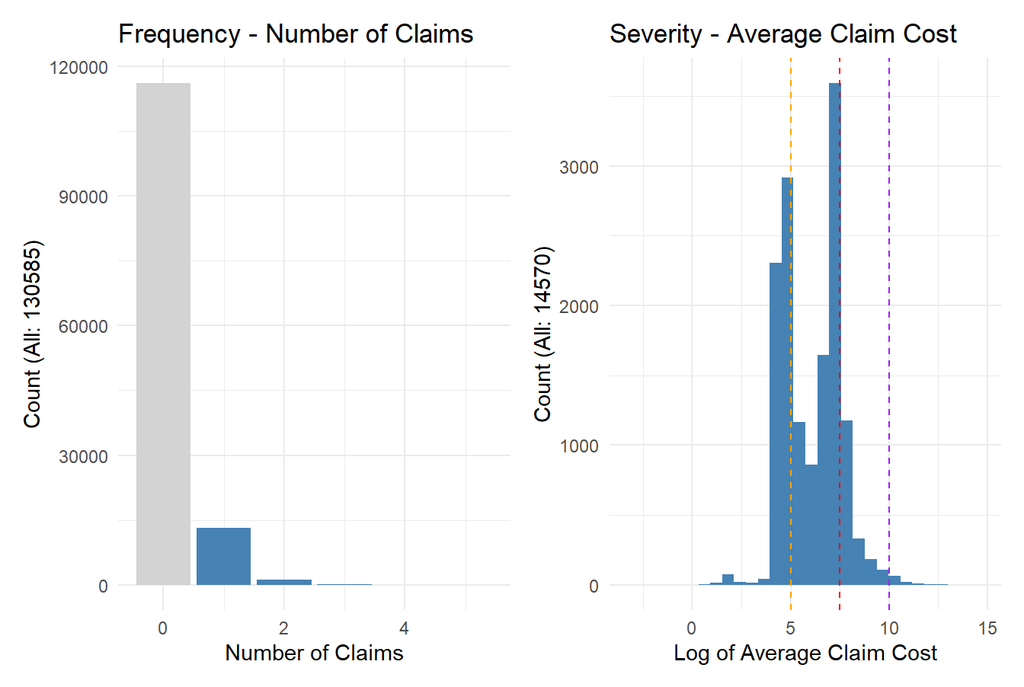

```r
p_n_claims <- ggplot(data, aes(x = NCLAIMS, fill = NCLAIMS == 0)) +
    geom_bar() +
    scale_fill_manual(values = c("TRUE" = "lightgrey", "FALSE" = "steelblue")) +
    labs(
        title = "Frequency - Number of Claims",
        y = sprintf("Count (All: %d)", nrow(data)),
        x = "Number of Claims"
    ) +
    guides(fill = "none") +
    theme_minimal()

avg_plot <- data %>% filter(!is.na(AVG))

p_avg <- ggplot(avg_plot, aes(x = log(AVG), fill = NCLAIMS == 0)) +
    geom_histogram(bins = 30) +
    scale_fill_manual(values = c("TRUE" = "lightgrey", "FALSE" = "steelblue")) +
    labs(
        title = "Severity - Average Claim Cost",
        x = "Log of Average Claim Cost",
        y = sprintf("Count (All: %d)", nrow(avg_plot))
    ) +
    geom_vline(aes(xintercept = 5), linetype = "dashed", color = "orange") +
    geom_vline(aes(xintercept = 7.5), linetype = "dashed", color = "red") +
    geom_vline(aes(xintercept = 10), linetype = "dashed", color = "purple") +
    guides(fill = "none") +
    theme_minimal()

p_n_claims | p_avg
```

For the number of claims, we observe a clear imbalance in the data with 88.84% of the policies having no claims. This is quite typical in insurance data, where many policies have no claims or very low average claim costs. We could tackle this data imbalance with dedicated techniques such as:

- Synthetic oversampling techniques (e.g., SMOTE) create synthetic samples for the minority class to balance the dataset.
- Hurdle models can be employed to separately model the zero and non-zero counts, effectively handling the excess zeros in the data and focusing on the non-zero records in the second part of the model.

These techniques will however break the adequation between the observed frequency and the modeled frequency which is an important benefit of the modeling approach that we will present in the next section. We will therefore not apply these techniques in this analysis.

For policies with claims, we look at the log of the average claim cost to better understand the distribution of claim severity in terms of magnitude. We observe two peaks and a long right tail. This shows that the average claim cost we computed above actually hides very different types of claims:

- First peak corresponds to small dents and repairs: the log around 5 represents claims of approximately 148 euros
- Second peak corresponds to more significant repairs: the log around 7.5 represents claims of approximately 1808 euros
- Right tail corresponds to way bigger damages: the log around 10 represents claims of approximately 22026 euros

Even if they are not so frequent, the larger claims in the right tail can have a significant impact on the company profitability. A future report could use `Extreme Value Theory` to better model and understand these rare but impactful claims. We will not apply this technique in the current analysis.

## 2.3 Approach

The goal of this report is to estimate the expected claim cost for different policies, taking into account both the frequency and severity of claims. Here is an overview of the main steps we will follow to achieve this goal:

1. **Data Preparation**: The goal of the data preparation is to go towards the modeling stage with clean, well-structured, and informative features only.
   - *Data Transformation*
     - Transform categorical variables to factors and set appropriate reference levels
     - Bin numerical variables using a weight of evidence (WoE) approach to create meaningful intervals for modeling
   - *Data Exploration*
     - Visualize graphically the claim frequency and severity distributions across variables
     - Statistically verify if variables are significant and whether merging levels is appropriate
   - *Feature Engineering*
     - Add geospatial features based on the location to capture urban v. rural and population density effects
     - Assess polynomial and orthogonal polynomial transformations to provide a baseline for capturing non-linear effects in numerical variables
     - Uncover interactions between variables based on a decision tree model
2. **Frequency Modeling**: The frequency modeling will compare increasingly complex models and compare their performance. For each layer of complexity, we will fit the model, prune non-significant variables, and test that the model captures more information than the previous layer with an anova test.
   - *Validation Framework*
     - Define data preparation pipeline to mirror EDA steps and ensure consistency between exploration and modeling
     - Set performance evaluation metrics and cross-validation strategy
   - *Generalized Linear Models (GLM) - Poisson(log)*
     - Categorical variables only (fit, prune, and test)
     - Binned numerical variables added (fit, prune, and test)
     - Enriched features added (fit, prune, and test)
     - Interactions added (fit, prune, and test)
     - Summarize the cross-validated prediction error, deviance, and log loss to select the best model (one per layer of complexity)
   - *Generalized Additive Models (GAM) - Poisson(log)*
     - Show the GAM logic through manual backfitting for latitude and longitude variables
     - Take the model from the categorical variables only layer as the baseline, add enriched features and continuous variables and fit, prune, and test the model
     - Vizualise the smoothed functions for continuous variables and compare them to the binned numerical variable effects and polynomial transformations
   - *Final Frequency Model*
     - Evaluate the various options based on the holdout to confirm the final technical model choice.
     - Merge levels with similar effects to simplify the model and improve interpretability
     - Remove sensitive variables to comply with regulatory requirements and ensure fairness
     - Interpret the final commercial model coefficients
3. **Severity Modeling**
   - *Validation Framework*
     - Adapt the metrics to the gamma family, considering the log link and the specific characteristics of the severity modeling
   - *Generalized Linear Models (GLM) - Gamma(log)[^8]*:
     - Show that modeling the average claim cost with the number of claims as weights is equivalent to modeling the total claim cost with the log number of claims as an offset.
     - Apply the same approach as for the frequency modeling, with cross-validation and performance evaluation metrics for different layers of complexity
   - *Final Severity Model*: the same logic of confirming, simplifying, and interpreting the technical model applies here as well
4. **Premium Modeling**
   - *Combined Model*
     - Combine the frequency and severity models to obtain the overall premium prediction
     - Rescale the severity intercept to ensure observation-prediction alignment
   - *Interpretation*
     - Interpret the combined coefficients
     - Show the resulting premium predictions for various policyholder classes

Note that the report goes into technical details. Depending on the reader’s familiarity with statistical modeling and interest, the following sections can be considered as bonus explorations:

- WoE (Weight of Evidence) Binning for numerical variables: a simpler quantile-based approach would have been sufficient for the scope of this assignment
- Feature engineering: creating new variables was not directly in the scope of this assignment
- Commercial model simplification: merging similar levels and removing sensitive variables was applied to improve interpretability

# 3 Data Preparation

## 3.1 Data Transformation

### 3.1.1 Categorical Variables

As concluded at the end of the last section, we need to transform some character variables to factor variables. We will also make sure that the most frequent level (Center in the section on all variables overview) is set as the reference level for unordered factor variables.

```r
for (col in c("COVERAGE", "FUEL", "USE", "FLEET", "SEX", "TOWN", "PC")) {
    data[[col]] <- as.factor(data[[col]]) %>% fct_infreq()
}
```

We can then assert that the categorical variables (ordered or unordered) have the correct reference levels. Note that our function also checks for ordered factor variables, ensuring that the reference level is the lowest level in this case. This does not happen in our dataset. The variable `BM` could be considered as unordered as we know that a higher `BM` score indicates a more risky driver but we don’t know if the jumps between the levels are constant. We decided to treat it as numerical because the numeric variable will be binned with a weight of evidence (WoE) approach to capture non-linearity and it will yield more meaningful bins than simple singleton bins.

```r
assert_ref_level <- function(data, cols) {
    for (col in cols) {
        if (!is.factor(data[[col]])) stop(paste(col, "is not a factor variable"))
        if (is.ordered(data[[col]])) {
            if (as.numeric(levels(data[[col]]))[1] != min(as.numeric(as.character(data[[col]])), na.rm = TRUE)) {
            # Pay attention to turn labels as numeric and not the factor internal codes which are just integers starting from 1
                stop(paste("Reference level for", col, "is not the lowest level"))
            }
        } else {
            if (
                levels(data[[col]])[1] !=
                    fct_count(data[[col]], sort = TRUE)$f[1]
            ) {
                stop(
                    paste(
                        "Reference level for", col,
                        "is not the most frequent level"
                    )
                )
            }
    }
    }
    cat("Reference levels for", paste(cols, collapse = ", "), "are correctly set\n")
}
assert_ref_level(data,  c("COVERAGE", "FUEL", "USE", "FLEET", "SEX", "TOWN", "PC"))
```

```
Reference levels for COVERAGE, FUEL, USE, FLEET, SEX, TOWN, PC are correctly set
```

### 3.1.2 Numerical Variables Binning

For the `Generalized Linear Model (GLM)` modeling, the continuous numerical variables can be used but this assumes that:

- The effect of one increment of the numerical variable on the target is assumed to be linear (age 18 to 19 has the same effect as age 50 to 51 which may not be realistic as experience marginal returns are likely diminishing).
- The linearity assumption may not hold for all numerical variables, and discretizing them into bins can help capture non-linear relationships with the target.

For these reasons, we will discretize the continuous numerical variables into bins. Defining optimal binning for a numerical variable is a complex task. There are a set of naive approaches that can be used:

- Singleton bins: Each unique value of the numerical variable is treated as a separate bin.
- Equal-width bins: The range of the variable is divided into intervals of equal width.
- Equal-frequency bins: Quantiles of the variable are used to create bins with approximately the same number of observations.

For this project, we will implement an approach based on weight of evidence (WoE) to capture the distribution of the target variable across different ranges of the numerical variable. The idea of WoE binning is to group values based on how strongly they are associated with the target variable (binary outcome encoded as good if claim = 0 and bad if claim >= 1):

$$\text{WoE_j} = \ln
\frac{\text{proportion of Good Outcomes in the bin j}}{\text{proportion
of Bad Outcomes in the bin j}}$$

Based on the WoE values for each bin $j$, the information value (IV) can be calculated for each variable, which measures the predictive power of the variable with respect to the target. The IV is calculated as:

$$\text{IV} = \sum_j (\text{proportion of
Good Outcomes in the bin j} - \text{proportion of Bad Outcomes in the
bin j}) \times \text{WoE_j}$$

The IV value helps to assess the predictive power of a variable for the binning we have chosen. The idea of the algorithm will be to:

1. Start with an adapted quantile-based binning as a baseline with a maximum number of bins specified.
2. Iteratively merge bins based on bins contribution to the information value (IV) and assess the variable IV after each merge.
3. Find the elbow point where the marginal contribution of one additional bin to the total IV decreases significantly.

We will take that elbow point and its associated bins boundaries for the final binning of the variable. We will detail each step of the algorithm with an example using the `AGEPH` variable.

#### 3.1.2.1 Baseline Quantile Binning

Our function `qbinning` provides a small improvement over standard quantile binning by starting from the maximum number of bins specified by `max_bins` then iteratively reducing the number of bins until each bin contains at least one claim. This will ensure that the weight of evidence (WoE) can be calculated for each bin, as each bin will have at least one claim. We’ll then avoid having an undefined WoE.

```r
qbinning <- function(data, x, y, max_bins = 10) {
    "Quantile-based binning for numerical variable x with respect to binary target y"
    if (sum(data[[y]] >= 1) == 0) stop("No claims in the dataset")
    if (sum(data[[y]] == 0) == 0) stop("No non-claims in the dataset")
    if (!is.numeric(data[[x]])) stop("Variable x must be numeric")
    raw_data <- data
    temp_n <- max_bins
    temp_binning <- NULL
    baseline_bins <- NULL
    while (temp_n > 1) {
        temp_binning <- unique(
            quantile(raw_data[[x]], probs = seq(0, 1, length.out = temp_n + 1), na.rm = TRUE)
        )
        bin_claims <- tapply(
            raw_data[[y]],
            cut(raw_data[[x]], temp_binning, include.lowest = TRUE),
            function(z) sum(z >= 1))
        if (all(bin_claims > 0)) {
            baseline_bins <- temp_binning
            break
        }
        temp_n <- temp_n - 1
    }
    baseline_bins
}
```

```r
bins_ageph <- qbinning(data, x = "AGEPH", y = "NCLAIMS", max_bins = 30)
counts <- tapply(
    data[["NCLAIMS"]],
    cut(data[["AGEPH"]], bins_ageph, include.lowest = TRUE),
    function(z) sum(z >= 1)
)

df_bins <- data.frame(
    bin = factor(names(counts), levels = names(counts)),
    count = as.numeric(counts)
)

p <- ggplot(df_bins, aes(x = bin, y = count)) +
ggtitle("Baseline Quantile Binning (AGEPH)") +
geom_col(fill = "steelblue") +
labs(x = "AGEPH baseline quantile bin", y = "Policies with at least one claim") +
theme_minimal() +
theme(axis.text.x = element_text(angle = 60, hjust = 1))
ggplotly(p)
```

[interactive chart not shown]

#### 3.1.2.2 Weight of Evidence (WoE) and Information Value (IV) Calculation

Based on the formula presented above, the weight of evidence (WoE) for each bin can be calculated as the natural logarithm of:

- $\text{proportion of Good Outcomes in the bin} = \frac{\text{Number of Good Outcomes in the bin}}{\text{Total Number of Good Outcomes}}$
- $\text{proportion of Bad Outcomes in the bin} = \frac{\text{Number of Bad Outcomes in the bin}}{\text{Total Number of Bad Outcomes}}$

If the bin has as many good (no claim) as bad (at least one claim) outcomes, the WoE will be zero as there is very little predictive power in that bin. If the bin has more good outcomes than bad outcomes, the WoE will be positive, indicating that the bin is associated with a lower risk. Finally, if the bin has more bad outcomes than good outcomes, the WoE will be negative, indicating that the bin is associated with a higher risk. The IV quantifies the overall predictive power based on the differences in the distribution of good and bad outcomes and the corresponding WoE values for each bin.

```r
woe_calc <- function(data, x, y, bins) {
    "Calculate Weight of Evidence (WoE) for each bin"
    woe_df <- data
    binned_woe <- tapply(
        woe_df[[y]],
        cut(woe_df[[x]], bins, include.lowest = TRUE),
        function(z) c(good = sum(z == 0), bad = sum(z >= 1))
    )
    binned_woe_df <- data.frame(
        bin = factor(names(binned_woe), levels = names(binned_woe)),
        good = sapply(binned_woe, function(x) x["good"]),
        bad = sapply(binned_woe, function(x) x["bad"])
    )
    rownames(binned_woe_df) <- NULL
    binned_woe_df$prop_good <- binned_woe_df$good / sum(binned_woe_df$good)
    binned_woe_df$prop_bad <- binned_woe_df$bad / sum(binned_woe_df$bad)
    binned_woe_df$woe <- log(binned_woe_df$prop_good / binned_woe_df$prop_bad)
    binned_woe_df$iv <- iv <- (binned_woe_df$prop_good - binned_woe_df$prop_bad) * binned_woe_df$woe
    return(binned_woe_df)
}

plot_woe_iv <- function(woe_df, interactive = TRUE) {
    max_woe <- max(abs(woe_df$woe))
    max_iv <- max(abs(woe_df$iv))
    # Avoid dividing by zero when all values are zero
    scale_factor <- if (max_woe > 0 && max_iv > 0) {
        max_woe / max_iv
    } else {
        1
    }
    p <- ggplot(woe_df, aes(x = bin)) +
        geom_col(
            aes(y = woe, fill = woe > 0),
            width = 0.8,
            show.legend = FALSE
        ) +
        scale_fill_manual(
            values = c("FALSE" = "firebrick", "TRUE" = "forestgreen")
        ) +
        geom_line(
            aes(y = iv * scale_factor, group = 1),
            color = "blue"
        ) +
        geom_point(
            aes(y = iv * scale_factor),
            color = "blue",
        ) +
        scale_y_continuous(
            name = "WoE and Scale-adjusted IV"
        ) +
        labs(x = "Bins") +
        theme_minimal() +
        theme(
            axis.text.x = element_text(angle = 60, hjust = 1),
        ) +
        ggtitle(
            paste0("WoE and IV (bins=", length(woe_df$bin), ")")
        )
    if (interactive) {
        ggplotly(p)
    } else {
        return(p)
    }
}
```

```r
woe_ex <- woe_calc(data, x = "AGEPH", y = "NCLAIMS", bins = bins_ageph)
plot_woe_iv(woe_ex)
```

[interactive chart not shown]

The example for `AGEPH` shows interesting patterns for our baseline binning:

- The WoE values go from negative to positive, indicating that the younger age groups have a higher likelihood of bad outcomes (at least one claim) compared to the older age groups.
- The IV line[^9] shows a high contribution from the young and some contribution of older age groups, with little contribution from the middle-aged bins.

The relationship between age and number of claims can be confirmed visually:

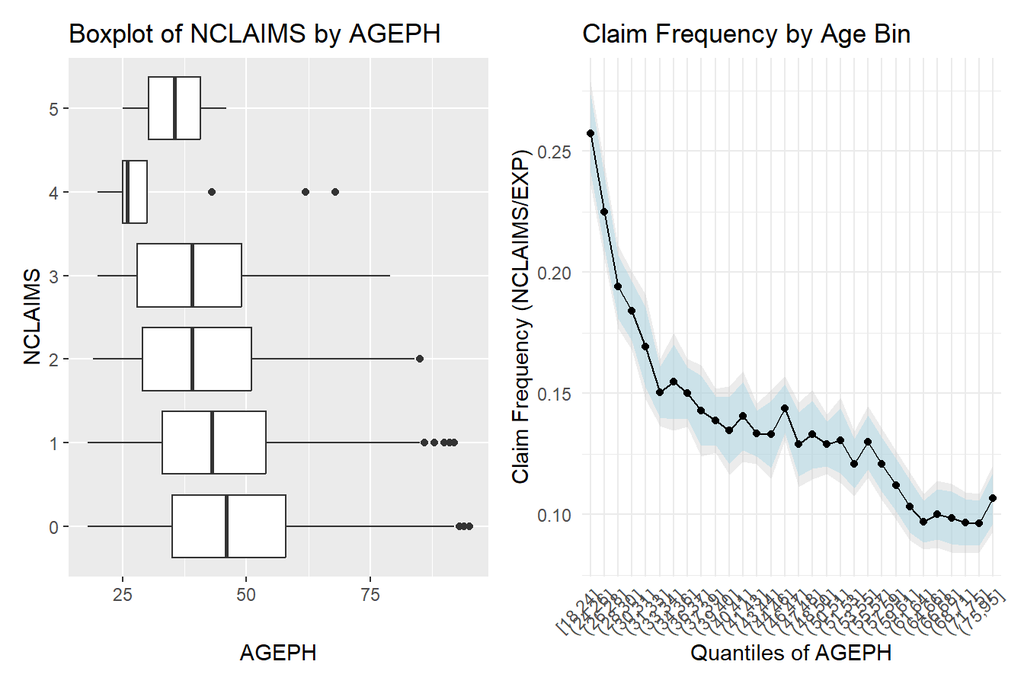

```r
p1 <- ggplot(data, aes(y = factor(NCLAIMS), x = AGEPH)) +
    geom_boxplot() +
    xlab("AGEPH") +
    ylab("NCLAIMS") +
    ggtitle("Boxplot of NCLAIMS by AGEPH")
age_quantiles <- cut(data$AGEPH, breaks = bins_ageph, include.lowest = TRUE)
gpd_data <- data %>%
    mutate(age_bin = age_quantiles) %>%
    group_by(age_bin) %>%
    summarise(
        sum_exp = sum(EXP),
        sum_claims = sum(NCLAIMS),
        lambda = sum_claims / sum_exp,
        sd_lambda = sqrt(lambda / sum_exp),
        lambda_95_lower = lambda - 1.96 * sd_lambda,
        lambda_95_upper = lambda + 1.96 * sd_lambda,
        lambda_99_lower = lambda - 2.58 * sd_lambda,
        lambda_99_upper = lambda + 2.58 * sd_lambda
    )

p2 <- ggplot(gpd_data, aes(x = age_bin, group = 1)) +
    geom_ribbon(
        aes(ymin = lambda_99_lower, ymax = lambda_99_upper),
        fill = "gray", alpha = 0.3, label = "99% CI"
    ) +
    geom_ribbon(
        aes(ymin = lambda_95_lower, ymax = lambda_95_upper),
        fill = "lightblue", alpha = 0.5, label = "95% CI"
    ) +
    geom_line(aes(y = lambda), color = "black") +
    geom_point(aes(y = lambda), color = "black") +
    theme_minimal() +
    scale_y_continuous(labels = scales::comma) +
    labs(
        x = "Quantiles of AGEPH",
        y = "Claim Frequency (NCLAIMS/EXP)",
        title = "Claim Frequency by Age Bin"
    ) +
    theme(axis.text.x = element_text(angle = 45, hjust = 1))

p1 | p2
```

The boxplot shows that the group of policyholders with lower amount of claims do tend to be older. The claim frequency plot by age bin with the confidence intervals[^10] reinforces this observation.

#### 3.1.2.3 Iterative Merging Based on Information Value (IV)

Remember that the Information Value (IV) is a measure based on the Weight of Evidence (WoE) that quantifies the predictive power of a feature in distinguishing between good and bad outcomes. It is calculated as:

$$\text{IV} = \sum_j (\text{proportion of
Good Outcomes in the bin j} - \text{proportion of Bad Outcomes in the
bin j}) \times \text{WoE of the bin j}$$

We have an information value for each bin, which allows us to identify the adjacent bins that contribute the least to the overall predictive power and merge them iteratively. The goal is to recursively merge the bin with lowest IV contribution with its neighboring bin, and evaluate the resulting IV. Then we can find the elbow point where further merging would lead to a significant loss of predictive power.

```r
iv_elbow <- function(data, x, y, bins) {
    "Recursively merge the bin with the lowest IV contribution with its neighboring bin with minimum IV"

    temp_bins <- bins
    temp_n_bins <- length(bins) - 1
    temp_woe_df <- woe_calc(data, x, y, temp_bins)
    temp_iv <- temp_woe_df$iv
    temp_total_iv <- sum(temp_iv)

    iter_log <- data.frame(
        n_bins = temp_n_bins,
        iv = temp_total_iv,
        bins = paste(temp_bins, collapse = ","),
        diff = NA,
        diff_order = NA
    )

    while(temp_n_bins > 2) {
        bin_to_merge <- which.min(temp_iv)
        if (bin_to_merge == 1) {
            neighbor <- 2
        } else if (bin_to_merge == temp_n_bins) {
            neighbor <- temp_n_bins - 1
        } else {
            neighbor <- ifelse(temp_iv[bin_to_merge - 1] < temp_iv[bin_to_merge + 1], bin_to_merge - 1, bin_to_merge + 1)
        }
        to_merge <- sort(c(bin_to_merge, neighbor))
        temp_bins <- temp_bins[-to_merge[2]]
        temp_n_bins <- length(temp_bins) - 1
        temp_woe_df <- woe_calc(data, x, y, temp_bins)
        temp_iv <- temp_woe_df$iv
        temp_total_iv <- sum(temp_iv)

        iter_log <- rbind(iter_log, data.frame(
            n_bins = temp_n_bins,
            iv = temp_total_iv,
            bins = paste(temp_bins, collapse = ","),
            diff = NA,
            diff_order = NA
        ))
    }
    iter_log <- iter_log %>% arrange(n_bins)
    iter_log$diff <- c(NA, abs(diff(iter_log$iv)))
    iter_log$diff[is.na(iter_log$diff)] <- 0
    iter_log$diff_order <- rank(-iter_log$diff)
    return(iter_log)
}
plot_iv_elbow <- function(iv_elbow_result, interactive = TRUE) {
    first_max_diff <- filter(iv_elbow_result, diff_order == 1)
    p <- ggplot(iv_elbow_result, aes(x = n_bins, y = iv)) +
        geom_line() +
        geom_point() +
        labs(title = "Information Value Elbow Plot", x = "Number of Bins", y = "Information Value") +
        theme_minimal() +
        geom_vline(xintercept = first_max_diff$n_bins, linetype = "dashed", color = "red") +
        geom_hline(yintercept = first_max_diff$iv, linetype = "dashed", color = "red")
    if (interactive) {
        ggplotly(p)
    } else {
        return(p)
    }
}
```

```r
result_named_list <- list()
n_bins_named_list <- list()
result_ageph <- iv_elbow(data, "AGEPH", "NCLAIMS", bins_ageph)
result_named_list[["AGEPH"]] <- result_ageph
plot_iv_elbow(result_ageph, interactive = TRUE)
```

[interactive chart not shown]

Looking at the IV elbow plot and taking the number of bins corresponding to the first maximum difference in IV as the optimal choice, we can rebuild the bins with only three bins. Adding a single bin seems sensible as we capture more information with a single additional split. We could also consider 7 or 12 bins that mark other pivotal points in the IV - Number of Bins relationship.

```r
rebuild_bins <- function(iv_elbow_result, n) {
    "Rebuild bins based on the IV elbow result for the specified number of bins"
    target_row <- iv_elbow_result %>% filter(n_bins == n)
    bins <- as.numeric(unlist(strsplit(target_row$bins, ",")))
    return(bins)
}
```

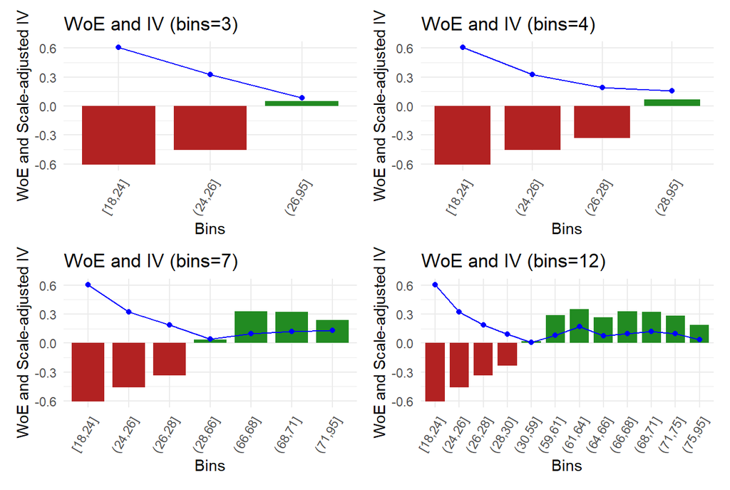

```r
plots <- list()
for (i in c(3, 4, 7, 12)) {
    temp_bins <- rebuild_bins(result_ageph, i)
    woe_temp <- woe_calc(data, x = "AGEPH", y = "NCLAIMS", bins = temp_bins)
    plots[[i]] <- plot_woe_iv(woe_temp, interactive = FALSE)
}
(plots[[3]] | plots[[4]] ) / (plots[[7]] | plots[[12]])
```

Based on the comparison above, the optimal amount of bins seems to be 7 because:

- We capture in fine granularity the effet of young ages with higher risk.
- We skip the middle of the age distribution which brings no additional information (28 to 66).
- We capture the effect of older ages with lower risk profiles with good granularity.

The complex pattern we noticed in our initial 30 bins seems to be well captured with 7 bins only.

```r
data$AGEPH_binned <- cut(
    data$AGEPH,
    breaks = rebuild_bins(result_ageph, 7), include.lowest = TRUE, ordered_result = TRUE)

n_bins_named_list[["AGEPH"]] <- 7
```

Now that the step by step approach has been clarified, the other continuous variables will be binned following a similar procedure.

#### 3.1.2.4 Bonus-Malus Binning (BM)

```r
baseline_bm <- qbinning(data, x = "BM", y = "NCLAIMS", max_bins = 30)
result_bm <- iv_elbow(data, "BM", "NCLAIMS", baseline_bm)
result_named_list[["BM"]] <- result_bm
plot_iv_elbow(result_bm, interactive = TRUE)
```

[interactive chart not shown]

Based on the Elbow plot for the Bonus-Malus (`BM`), let’s try 3, 4, 5, and 11 bins.

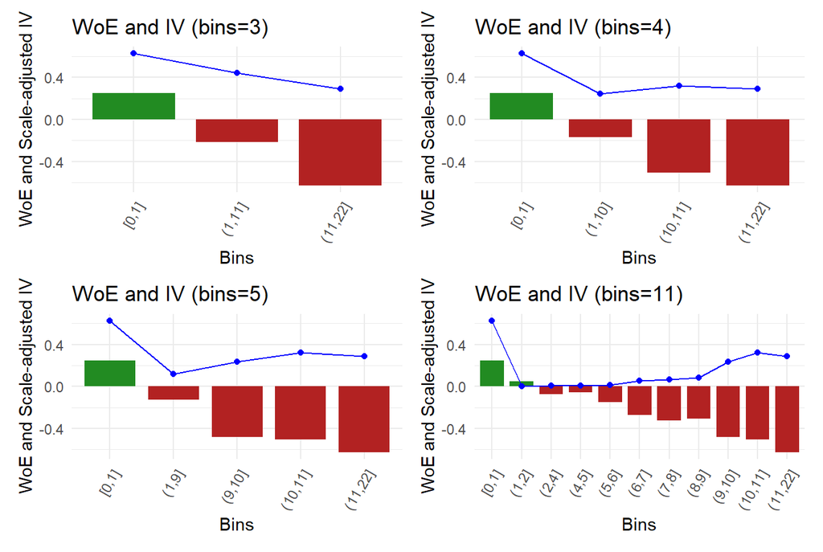

```r
plots_bm <- list()
for (i in c(3, 4, 5, 11)) {
    temp_bins_bm <- rebuild_bins(result_bm, i)
    woe_temp_bm <- woe_calc(data, x = "BM", y = "NCLAIMS", bins = temp_bins_bm)
    plots_bm[[i]] <- plot_woe_iv(woe_temp_bm, interactive = FALSE)
}
(plots_bm[[3]] | plots_bm[[4]] ) / (plots_bm[[5]] | plots_bm[[11]])
```

We see that most information is captured by the first bin indicating that those with a BM of 0 are significantly safer than the others. The three bins are sufficient to capture the first group at bonus-malus zero, then the first and second risk groups that are the first and second half of the BM score. Adding bins just creates bins in between with low informational value.

```r
data$BM_binned <- cut(
    data$BM,
    breaks = rebuild_bins(result_bm, 3), include.lowest = TRUE, ordered_result = TRUE)
n_bins_named_list[["BM"]] <- 3
```

#### 3.1.2.5 Age of the Car Binning (AGEC)

```r
baseline_agec <- qbinning(data, x = "AGEC", y = "NCLAIMS", max_bins = 30)
result_agec <- iv_elbow(data, "AGEC", "NCLAIMS", baseline_agec)
result_named_list[["AGEC"]] <- result_agec
plot_iv_elbow(result_agec, interactive = TRUE)
```

[interactive chart not shown]

For the age of the car (`AGEC`), we also see a plateau after around 5 and 9 bins, let’s compare 3, 5, 9 and 16 (max) bins.

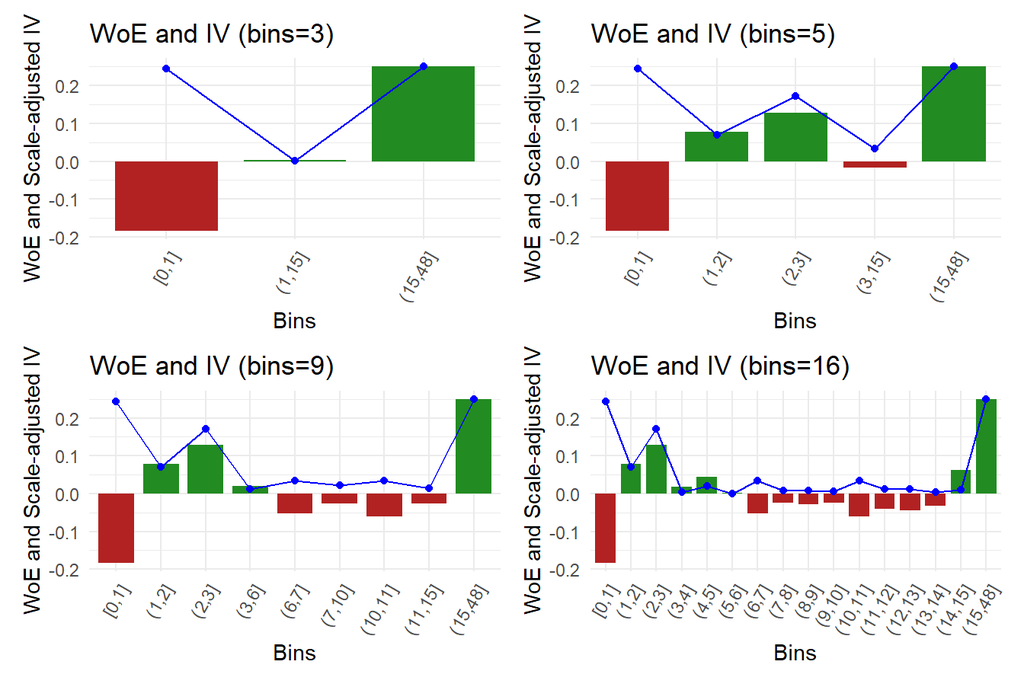

```r
plots_agec <- list()
for (i in c(3, 5, 9, 16)) {
    temp_bins_agec <- rebuild_bins(result_agec, i)
    woe_temp_agec <- woe_calc(data, x = "AGEC", y = "NCLAIMS", bins = temp_bins_agec)
    plots_agec[[i]] <- plot_woe_iv(woe_temp_agec, interactive = FALSE)
}
(plots_agec[[3]] | plots_agec[[5]]) / (plots_agec[[9]] | plots_agec[[16]])
```

The maximum binning shows us a clear separation of risk between:

- Brand new cars (AGEC close to 0) have the highest risk.
- Older cars (AGEC over 15 years) have a lower risk.

This is captured from 3 bins onward. Using 5 bins would allow us to capture the low-risk group for cars of 1 to 3 years old separately from the older low-risk cars. These cars are typically good new cars with conductors that have had the time to get used to them. We will thereforeuse 5 bins for the age of the car.

```r
data$AGEC_binned <- cut(
    data$AGEC,
    breaks = rebuild_bins(result_agec, 5)
    , include.lowest = TRUE, ordered_result = TRUE)
n_bins_named_list[["AGEC"]] <- 5
```

#### 3.1.2.6 Power Binning (POWER)

```r
baseline_power <- qbinning(data, x = "POWER", y = "NCLAIMS", max_bins = 30)
result_power <- iv_elbow(data, "POWER", "NCLAIMS", baseline_power)
result_named_list[["POWER"]] <- result_power
plot_iv_elbow(result_power, interactive = TRUE)
```

[interactive chart not shown]

For the power of the car (`POWER`), we have stairs at 6, 8, and 13 bins. We’ll compare these three steps with the max level of bins (23).

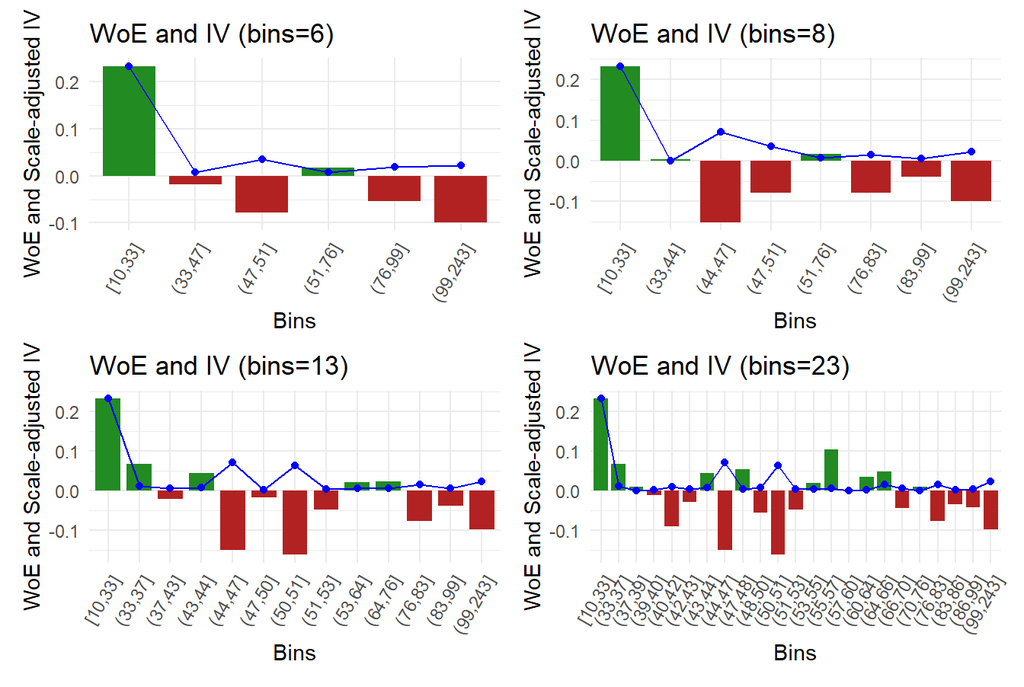

```r
plots_power <- list()
for (i in c(6, 8, 13, 23)) {
    temp_bins_power <- rebuild_bins(result_power, i)
    woe_temp_power <- woe_calc(data, x = "POWER", y = "NCLAIMS", bins = temp_bins_power)
    plots_power[[i]] <- plot_woe_iv(woe_temp_power, interactive = FALSE)
}
(plots_power[[6]] | plots_power[[8]]) / (plots_power[[13]] | plots_power[[23]])
```

- Power between 44 and 47: this is the minimum legal and practical power for modern highway-legal cars. Below this range, cars are typically underpowered for regular driving conditions.
- Power between 50 and 51: this is widely considered the mechanical sweet spot to maintain highway speed withouf sacrificing fuel economy in urban driving. It is typically a marker of entry-level city cars.

Based on this interpretation, the power could be a proxy for the type of car and its urban usage. We will use 8 bins to capture this bump risk pattern (44-47 and 47-51) without overcomplicating the model.

```r
data$POWER_binned <- cut(
    data$POWER,
    breaks = rebuild_bins(result_power, 8),
    include.lowest = TRUE, ordered_result = TRUE)
n_bins_named_list[["POWER"]] <- 8
```

We will end this Data Transformation section here now that we have bins for both categorical and numerical variables.

## 3.2 Data Exploration

### 3.2.1 Graphical Approach

For all our categorical and continuous variables, we will visualize explore their relationship with both the claim frequency and the average claim cost.

1. Visualizing the claim frequency for binned variables

The claim frequency and its confidence intervals can be calculated for each bin of the variables. If we assume that the number of claims follows a Poisson distribution, we can derive the MLE estimator for the claim frequency $\lambda \sim \text{Normal}\left(\hat{\lambda}, \frac{\hat{\lambda}}{\sum_i d_i}\right)$.[^demonstration]

$$NCLAIMS_{i} \sim
\text{Poisson}(d_i\times \lambda) \text{, where } d_i \text{ is the
exposure and } \lambda \text{ is the claim frequency}$$
$$\hat{NCLAIMS_i} \sim \text{Normal}(d_i \times
\lambda, d_i \times \lambda)$$
$$\hat{\lambda} = \frac{\sum_i NCLAIMS_i}{\sum_i
d_i}$$
$$\hat{\lambda} \sim
\text{Normal}\left(\frac{\sum_i d_i \lambda}{\sum_i d_i}, \frac{\sum_i
d_i \lambda}{(\sum_i d_i)^2}\right)$$
$$\hat{\lambda} \sim \text{Normal}\left(\lambda,
\frac{\lambda}{\sum_i d_i}\right)$$

The variance could also be derived from the inverse of the Fisher information ($=-\ell''(\widehat{\lambda})$):
$$\text{Var}(\widehat{\lambda}) \approx
\mathcal{I}(\widehat{\lambda})^{-1} = \frac{\widehat{\lambda}}{\sum_i
d_i}.$$

Based on this mathematical understanding, we can build a plot which shows exposures, claims, and claim frequencies with their confidence intervals (95 and 99%) across different bins for each variable.

```r
mean_claim_frequency <- sum(data$NCLAIMS) / sum(data$EXP)
plot_claim_freq <- function(data, variable) {
    df_grouped <- data %>%
        mutate(bin = data[[variable]]) %>%
        group_by(bin) %>%
        summarise(
            sum_exp = sum(EXP),
            sum_claims = sum(NCLAIMS),
            lambda = sum_claims / sum_exp,
            sd_lambda = sqrt(lambda / sum_exp),
            lambda_95_lower = lambda - 1.96 * sd_lambda,
            lambda_95_upper = lambda + 1.96 * sd_lambda,
            lambda_99_lower = lambda - 2.58 * sd_lambda,
            lambda_99_upper = lambda + 2.58 * sd_lambda
        )
    df_grouped$sum_no_claims <- df_grouped$sum_exp - df_grouped$sum_claims
    df_counts <- bind_rows(
        mutate(df_grouped, bin = bin, value = sum_claims, metric = "Claims"),
        mutate(df_grouped, bin = bin, value = sum_no_claims, metric = "No Claims")
    )
    p_counts <- ggplot(df_counts, aes(x = bin, y = value, fill = metric)) +
        geom_bar(stat = "identity") +
        scale_fill_manual(values = c("Claims" = "firebrick", "No Claims" = "lightgray")) +
        labs(x = variable, y = "Count", fill = "Metric") +
        theme(axis.text.x = element_text(angle = 45, hjust = 1)) +
        guides(fill = "none") +
        theme_minimal() +
        ggtitle("Exposure (Claims in Red)")
    p_freq <- ggplot(df_grouped, aes(x = bin, group = 1)) +
        geom_ribbon(
            aes(ymin = lambda_99_lower, ymax = lambda_99_upper),
            fill = "gray", alpha = 0.3
        ) +
        geom_ribbon(
            aes(ymin = lambda_95_lower, ymax = lambda_95_upper),
            fill = "lightblue", alpha = 0.5
        ) +
        geom_line(aes(y = lambda), color = "black") +
        geom_point(aes(y = lambda), color = "black") +
        geom_hline(yintercept = mean_claim_frequency, color = "red", linetype = "dashed") +
        theme_minimal() +
        labs(
            x = variable,
            y = "Claim Frequency (Lambda)",
        ) +
        theme(axis.text.x = element_text(angle = 45, hjust = 1)) +
        ggtitle("Claim Frequency")
    p_all <- p_freq / p_counts
    p_all
}
```

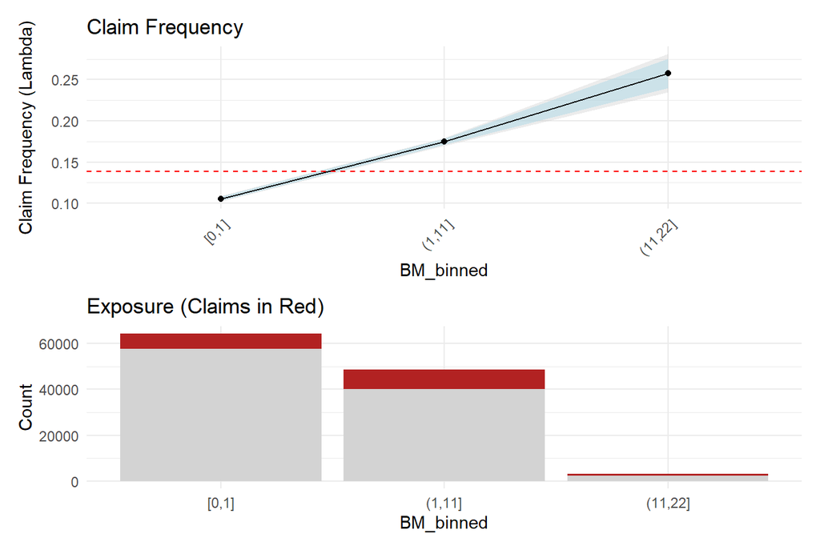

```r
plot_claim_freq(data, "BM_binned")
```

For this first example on the Bonus-Malus binned variable, we see a clear upward trend in the claim frequency as the Bonus-Malus level increases. This is expected as risky behaviour is translated in higher score on the BM scale. What is also interesting is that the claim frequency is a lot more precise for the 0 to 1 bin as the exposure is much higher compared to the higher BM levels. The confidence intervals also enable us to quickly test hypothesis that the claim frequency for a given bin is significantly different from the overall mean claim frequency (in red) or from other bins within the same variable[^12].

The same approach can be used to explore the claim frequency patterns for all other variables in the dataset.

2. Visualizing the average claim cost for binned variables

There is no closed form solution to find the variance of the average claim cost for a given bin (assuming a gamma distribution for average claim cost). We will instead fit a gamma regression model with the variable as single predictor to estimate the average claim cost and its confidence intervals for each bin. Note that we could either predict `AMOUNT` with an offset of `NCLAIMS` and weight of `NCLAIMS`[^13] or predict `AVG` with a weight of `NCLAIMS`.

```r
temp_data <- data
temp_data$BM_binned <- factor(temp_data$BM_binned, ordered = FALSE)
m_avg <- glm(
    formula = AVG ~ BM_binned,
    family = Gamma("log"),
    data = temp_data,
    subset = NCLAIMS > 0,
    weights = NCLAIMS
)
m_amount <- glm(
    formula = AMOUNT ~ offset(log(NCLAIMS)) + BM_binned,
    family = Gamma("log"),
    data = temp_data,
    subset = NCLAIMS > 0,
    weights = NCLAIMS
)
data.frame(
    AVG_coef = summary(m_avg)$coefficients[, "Estimate"],
    AMOUNT_coef = summary(m_amount)$coefficients[, "Estimate"],
    AVG_se = summary(m_avg)$coefficients[, "Std. Error"],
    AMOUNT_se = summary(m_amount)$coefficients[, "Std. Error"]
) %>% kable(
    caption = "Comparison of coefficients and standard errors for AMOUNT and AVG models",
    booktabs = TRUE
)
```

Comparison of coefficients and standard errors for AMOUNT and AVG models

|  | AVG_coef | AMOUNT_coef | AVG_se | AMOUNT_se |
| --- | --- | --- | --- | --- |
| (Intercept) | 7.2669949 | 7.2669949 | 0.1265565 | 0.1265565 |
| BM_binned(1,11] | 0.2667138 | 0.2667138 | 0.1697745 | 0.1697745 |
| BM_binned(11,22] | 0.3456541 | 0.3456541 | 0.3865095 | 0.3865095 |

We will use the prediction of `AVG` with a weight of `NCLAIMS` to visualize the average claim cost for binned variables.

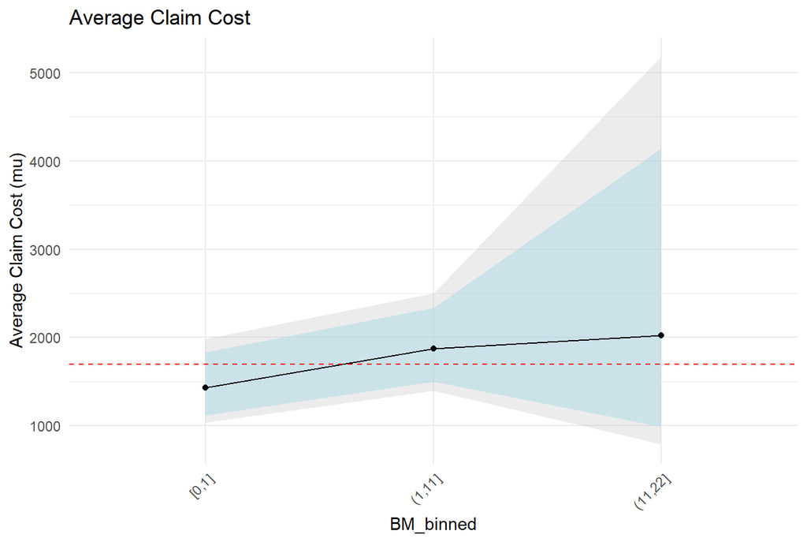

```r
mean_avg <- sum(data$AMOUNT) / sum(data$NCLAIMS)
plot_avg_claim_cost <- function(data, var) {
    mod <- glm(
        formula = as.formula(paste("AVG ~ ", var)),
        family = Gamma("log"),
        data = data,
        subset = NCLAIMS > 0,
        weights = NCLAIMS
    )
    pred_var <- data.frame(levels(data[[var]]))
    colnames(pred_var) <- var
    pred_var[[var]] <- factor(pred_var[[var]], levels = levels(data[[var]]))
    p <- predict(mod, newdata = pred_var, type = "link", se.fit = TRUE)
    pred_var$pred <- exp(p$fit)
    pred_var$se_link <- p$se.fit
    pred_var$lb_99 <- exp(p$fit + qnorm(0.005) * p$se.fit)
    pred_var$ub_99 <- exp(p$fit + qnorm(0.995) * p$se.fit)
    pred_var$lb_95 <- exp(p$fit + qnorm(0.025) * p$se.fit)
    pred_var$ub_95 <- exp(p$fit + qnorm(0.975) * p$se.fit)

    p_avg <- ggplot(pred_var, aes(x = .data[[var]], group = 1)) +
        geom_ribbon(
            aes(ymin = lb_99, ymax = ub_99),
            fill = "gray", alpha = 0.3
        ) +
        geom_ribbon(
            aes(ymin = lb_95, ymax = ub_95),
            fill = "lightblue", alpha = 0.5
        ) +
        geom_line(aes(y = pred), color = "black") +
        geom_point(aes(y = pred), color = "black") +
        geom_hline(yintercept = mean_avg, color = "red", linetype = "dashed") +
        theme_minimal() +
        labs(
            x = var,
            y = "Average Claim Cost (mu)",
        ) +
        theme(axis.text.x = element_text(angle = 45, hjust = 1)) +
        ggtitle("Average Claim Cost")
    return(p_avg)
}

plot_avg_claim_cost(data, "BM_binned")
```

3. Continuous Variables

For the `Generalized Additive Models` (GAM) approach, we will work with continuous variables instead of binned categorical variables. The visualization of their first, second, and third degree correlations will be addressed in the Feature Engineering - Polynomial section.

#### 3.2.1.1 Categorical Variables

```
> COVERAGE
```

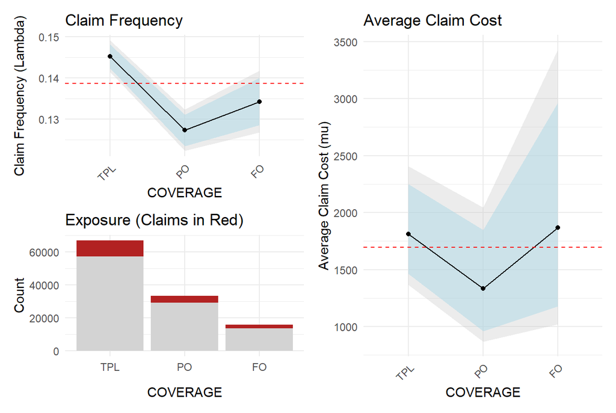

```
> FUEL
```

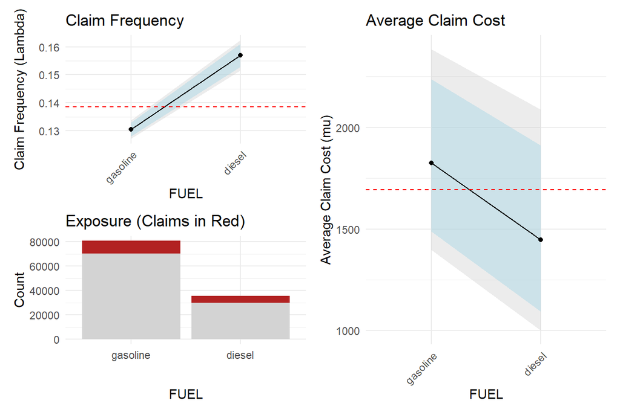

```
> USE
```

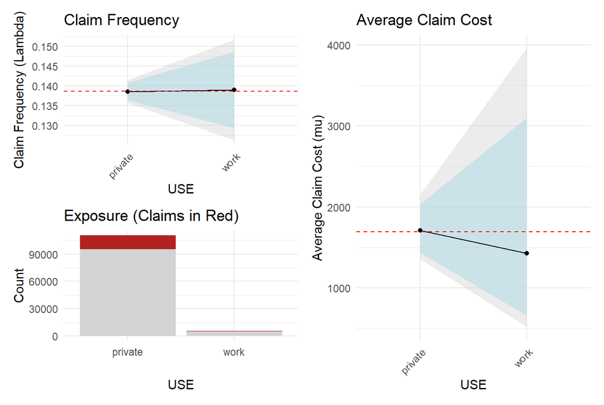

```
> FLEET
```

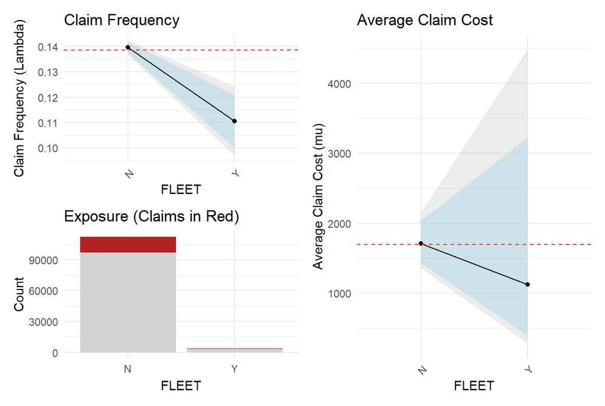

```
> SEX
```

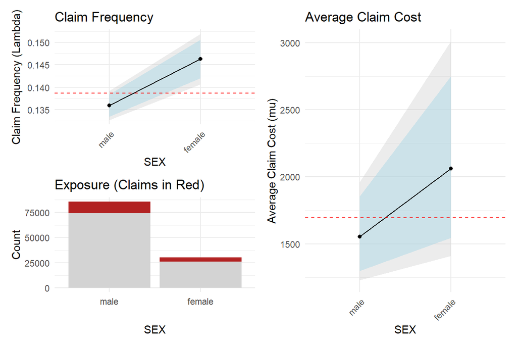

```r
plot_freq_sev <- function(data, cat_var) {
    p_freq <- plot_claim_freq(data, cat_var)
    p_sev <- plot_avg_claim_cost(data, cat_var)
    plot(p_freq | p_sev)
}
for (cat_var in c("COVERAGE", "FUEL", "USE", "FLEET", "SEX")) {
    cat(paste0("> ", cat_var, "\n"))
    plot_freq_sev(data, cat_var)
}
```

Based on the graphs, here are the preliminary conclusions for univariate analysis of categorical variables:

- `COVERAGE`

The claim frequency between partial and full omnium is statistically significant at the 5% level but not at the 1% level. However both are different from third-party liability only. It is interesting to see that the claim frequency is higher for these who choose lesser coverage. This can be interpreted as a proxy for risk-awareness, financial education, or even purchasing power. Based on the claim frequency only, we could merge the partial and full omnium to focus on the difference with third-party liability only. However, the average claim cost shows a clear difference between partial and full omnium. We will keep the three levels separate in our analysis to capture this distinction.

- `FUEL`

Diesel vehicles have significantly higher claim frequency compared to petrol vehicles. Looking at the average claim cost, we see an opposite trend, with petrol vehicles having higher average claim costs. This suggests that the total claim cost might be balanced between the higher frequency of diesel claims and the higher severity of petrol claims. Opposite effects of a variable on frequency and severity is the reason why we decided to model them separately instead of modeling the total claim cost directly.

- `USE`

Private and professional use show no statistical differences from one another, nor from the mean both in terms of claim frequency and average claim cost. We will not include this variable in our models to avoid noise. Note that the proportion of policies related to work is very low, this has three consequences:

1. The private use looks very similar to the average as it represents the majority of the policies.
2. The work use is to variable to be statistically significant due to its low representation.
3. The variable is too unbalanced to provide reliable insights for modeling purposes.
- `FLEET`

Let’s compare the graph for fleet to the one of `USE`. Here again, we have a very unbalanced variable.

Regarding the average claim cost, the trend seems to be similar to the claim frequency but with higher volatility due to the even lower amount of data available for the fleet category.

- `SEX`

Similarly to the interpretation for the `FLEET`, there is a significant difference in claim frequency even if one category is less represented than the other. In this case, the imbalance is less strong, the males are thus slightly further from the average and females are significantly more prone to claims than males. We see that the average claim cost for females is also higher than for males, showing a similar trend than for claim frequency.

#### 3.2.1.2 Numerical Variables

Let us now have a look at the binned numerical variables other than the bonus-malus scale that we already interpreted.

```
> AGEPH_binned
```

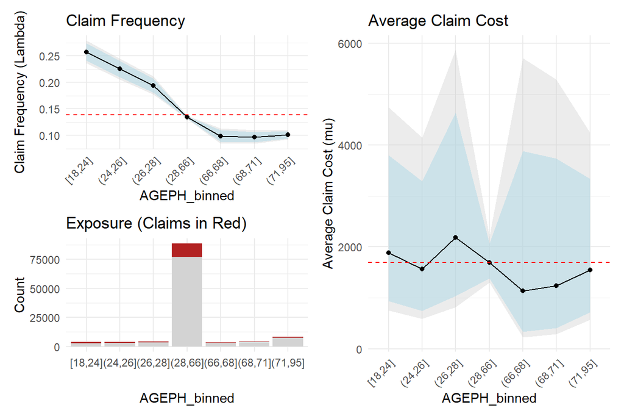

```
> AGEC_binned
```

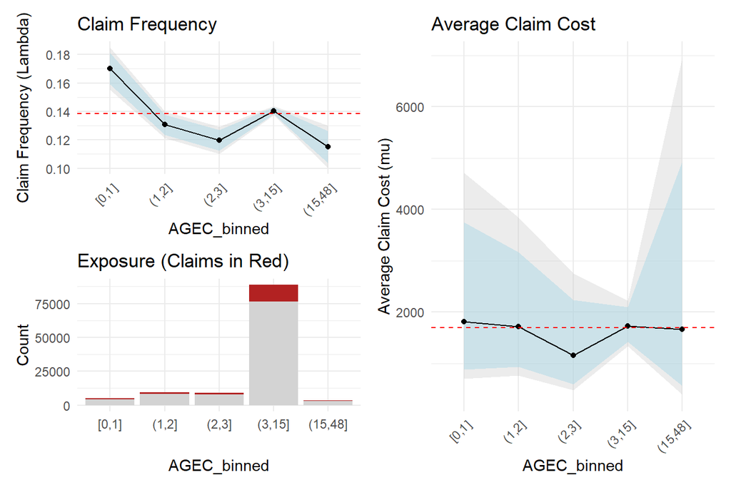

```
> POWER_binned
```

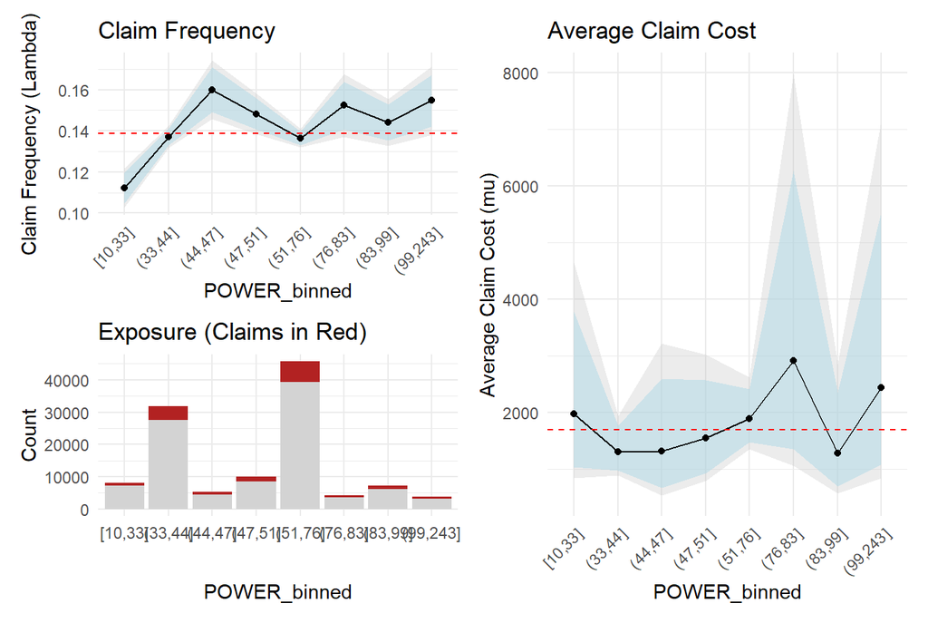

```r
for (cat_var in c("AGEPH_binned", "AGEC_binned", "POWER_binned")) {
    cat(paste0("> ", cat_var, "\n"))
    plot_freq_sev(data, cat_var)
}
```

- `AGEPH_binned`

We see the claim frequency diminution as the age of the policyholder increases as we identified with our binning algorithm. However, we see that the last three are not significantly different from one another in terms of claim frequency. We will come back to this in the statistical approach section and see with an anova test if the 7 bins are significantly better than a reduced number of bins. The average claim cost is also lower for older age groups but the trend is less clear for younger ages.

- `AGEC_binned`

For the age of the car, we can confirm our previous observations that brand new cars (0-1 years old) have more claims. We can also confirm the lower claim frequency for cars between 1 and 3 years old and above 15 years. The remaining question is whether the bins 1 to 2 and 2 to 3 should be merged in a single bin or not. We will revisit this question in the statistical approach section to determine if merging these bins significantly affects the model performance. Looking at average cost, we wee the downards trend for the first three levels and return to average for the vehicles above 3 years old.

- `POWER_binned`

Thanks to our binning algorithm, we correctly identified the low-risk for power lower than 33 kilowatts. We also correctly identified the very bump-shaped peak in risk for power 44 to 51 kilowatts. It is not clear whether the last 3 bins should be merged or kept separate, as the risk pattern is less pronounced in this range. We will also investigate this in the statistical approach section. The average cost of claims doesn’t show the bump for power between 44 and 51. While frequency can increase because these powers are proxies of entry-level city cars, the cost will not be higher for entry level cars. We instead see an increase in average cost from 33 kw to 83 kw. The variability afterwards makes it hard to interpret.

### 3.2.2 Statistical Approach

Besides visual inspection, we will use statistical tests to confirm the significance of each variable and of levels (for merging decision). We will focus on claim frequency for these statistical tests as the average cost estimates are a lot more variable and less reliable for significance testing. Two different anova tests will be used: variable-wise ANOVA tests to assess the overall significance of each variable, and level-wise ANOVA tests to determine if merging certain levels is statistically justified.

#### 3.2.2.1 Variable-wise ANOVA Tests

We will compare the deviance of the model with the variable as single predictor to the null model with only the offset term. This will allow us to test if the variable significantly improves the model fit:

$H_0: \Delta D = D_0 - D_1 = 0$

$H_1: \Delta D = D_0 - D_1 > 0$

For our test statistic we have $\Delta D \sim \chi^2_{df}$, where $df$ is the difference in the number of parameters between the null and alternative models.

Our $D_0$ represents the deviance of the null model with only the offset term: `glm(NCLAIMS ~ offset(log(EXP)), poisson(link = "log"))`.

The $D_1$ represents the deviance of the model with the variable as a single predictor: `glm(NCLAIMS ~ offset(log(EXP)) + get(var), poisson(link = "log"))`.

```r
m0 <- glm(NCLAIMS ~ offset(log(EXP)), data = data, family = poisson(link = "log"))
cat(sprintf("Because we use Poisson with its canonic link, note that exp(Beta0) = %f is equal to the empiric claim frequency = %f", exp(coef(m0)[1]), sum(data$NCLAIMS)/sum(data$EXP)))
```

```
Because we use Poisson with its canonic link, note that exp(Beta0) = 0.138624 is equal to the empiric claim frequency = 0.138624
```

Let’s now compare this null model to the models with each predictor variable individually.

```r
test_level <- 0.05
for (var in c("COVERAGE", "FUEL", "USE", "FLEET", "SEX", "BM_binned", "AGEPH_binned", "AGEC_binned", "POWER_binned")) {
    m1 <- glm(NCLAIMS ~ offset(log(EXP)) + get(var), data = data, family = poisson(link = "log"))
    test_result <- anova(m0, m1, test = "Chisq")
    cat(sprintf("Is variable %s significant? %s\n", var, ifelse(test_result$`Pr(>Chi)`[2] < test_level, "Yes", "No")))
}
```

```
Is variable COVERAGE significant? Yes
Is variable FUEL significant? Yes
Is variable USE significant? No
Is variable FLEET significant? Yes
Is variable SEX significant? Yes
Is variable BM_binned significant? Yes
Is variable AGEPH_binned significant? Yes
Is variable AGEC_binned significant? Yes
Is variable POWER_binned significant? Yes
```

With this first variable-wise anova test, we confirm our graphical approach that all variables should be kept except for `USE`.

#### 3.2.2.2 Level-wise ANOVA Tests

Let’s take the example of `COVERAGE` where we visually observed that the two omnium levels were significantly different at the 95% confidence level but not at the 99% confidence level. We will confirm this observation using a level-wise ANOVA test, comparing the models based on merged and unmerged levels.

```r
data$COVERAGE_BIN <- fct_collapse(
    data$COVERAGE,
    "OMN" = c("PO", "FO")
)
m0 <- glm(NCLAIMS ~ offset(log(EXP)) + COVERAGE_BIN, data = data, family = poisson(link = "log"))
m1 <- glm(NCLAIMS ~ offset(log(EXP)) + COVERAGE, data = data, family = poisson(link = "log"))
test_result <- anova(m0, m1, test = "Chisq")
pval <- test_result$`Pr(>Chi)`[2]
cat(sprintf("Is it justified to merge the omnium levels at 95%% confidence level? %s", ifelse(pval < 0.05, "No", "Yes")))
```

```
Is it justified to merge the omnium levels at 95% confidence level? No
```

```r
cat(sprintf("Is it justified to merge the omnium levels at 99%% confidence level? %s", ifelse(pval < 0.01, "No", "Yes")))
```

```
Is it justified to merge the omnium levels at 99% confidence level? Yes
```

Because the p-value is 0.0469242, we can conclude that we reject the hypothesis that the deviance was different between the merged and unmerged COVERAGE bins at a 95% confidence level but not at a 99% confidence level. Because of our graphical analysis, we will keep the omnium levels separate because of their impact on average claim cost.

We can apply the same reasoning to clarify whether or not we should merge:

- The last 3 bins of `AGEPH_binned`

```
Merging the last 3 bins of AGEPH_binned was justified (p-value = 0.750730).
```

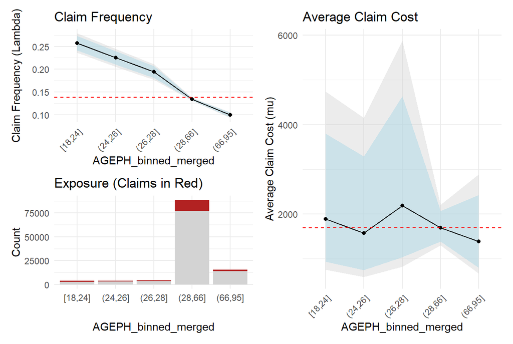

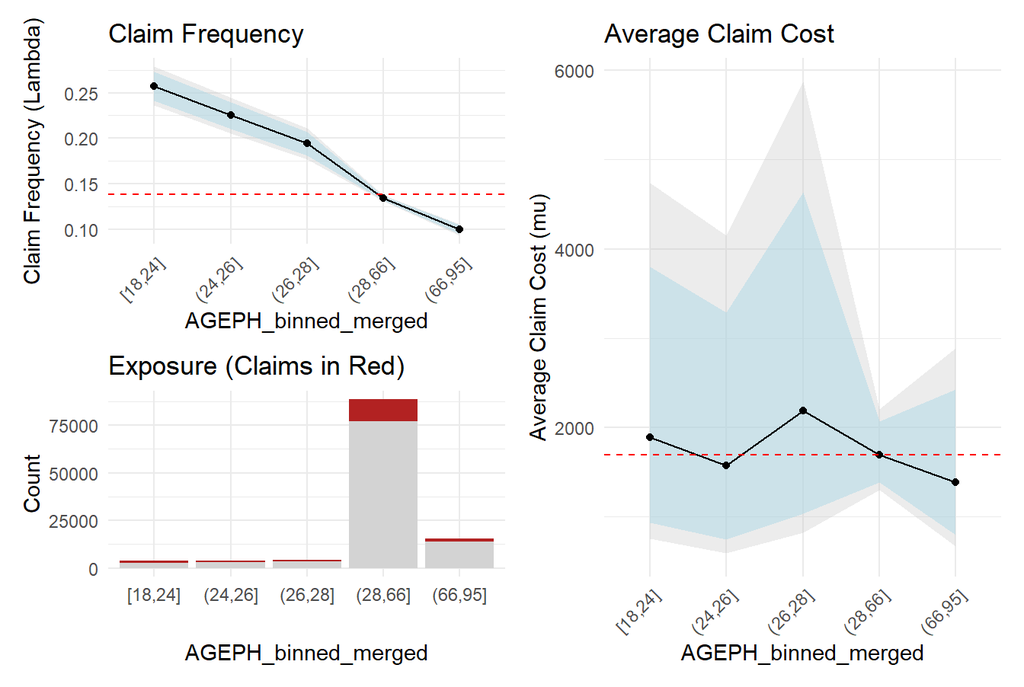

```r
data$AGEPH_binned_merged <- fct_collapse(
    data$AGEPH_binned,
    "(66,95]" = c("(66,68]", "(68,71]", "(71,95]")
)

m0 <- glm(NCLAIMS ~ offset(log(EXP)) + AGEPH_binned, data = data, family = poisson(link = "log"))
m1 <- glm(NCLAIMS ~ offset(log(EXP)) + AGEPH_binned_merged, data = data, family = poisson(link = "log"))
test_result <- anova(m0, m1, test = "Chisq")
pval <- test_result$`Pr(>Chi)`[2]

if(pval < 0.05) {
    cat(sprintf("Merging the last 3 bins of AGEPH_binned was not justified (p-value = %f).\n", pval))
    data$AGEPH_binned_merged <- NULL
} else {
    cat(sprintf("Merging the last 3 bins of AGEPH_binned was justified (p-value = %f).\n", pval))
    plot(plot_freq_sev(data, "AGEPH_binned_merged"))
}
```

- The bins 1-2 and 2-3 of `AGEC_binned`

```r
data$AGEC_binned_merged <- fct_collapse(
    data$AGEC_binned,
    "(1,3]" = c("(1,2]", "(2,3]")
)

m0 <- glm(NCLAIMS ~ offset(log(EXP)) + AGEC_binned, data = data, family = poisson(link = "log"))
m1 <- glm(NCLAIMS ~ offset(log(EXP)) + AGEC_binned_merged, data = data, family = poisson(link = "log"))
test_result <- anova(m0, m1, test = "Chisq")
pval <- test_result$`Pr(>Chi)`[2]

if(pval < 0.05) {
    cat(sprintf("Merging the second and third bins of AGEC_binned was not justified (p-value = %f).\n", pval))
    data$AGEC_binned_merged <- NULL
} else {
    cat(sprintf("Merging the second and third bins of AGEC_binned was justified (p-value = %f).\n", pval))
    plot(plot_freq_sev(data, "AGEC_binned_merged"))
}
```

```
Merging the second and third bins of AGEC_binned was not justified (p-value = 0.036014).
```

- The last 3 bins of `POWER_binned`

```
Merging the last 3 bins of POWER_binned was justified (p-value = 0.307144).
```

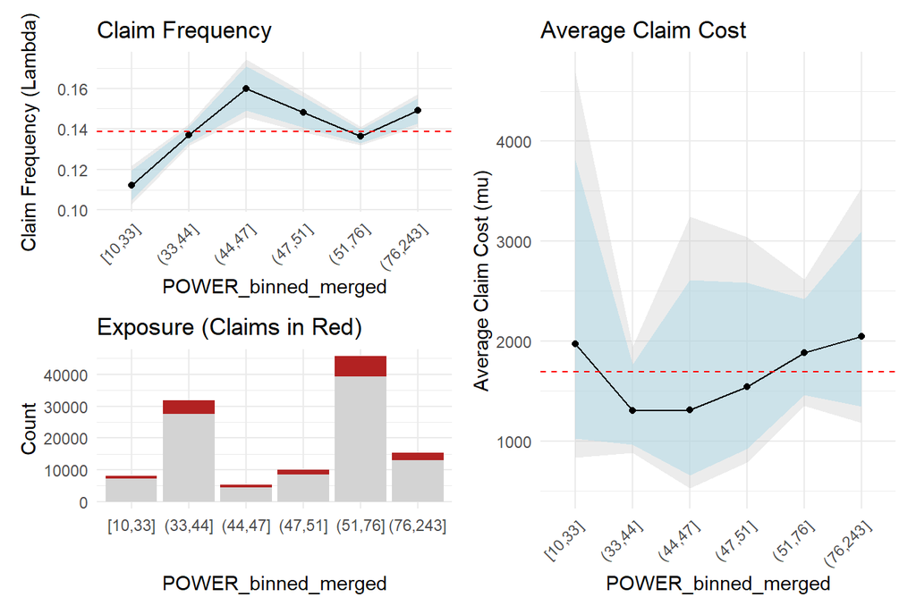

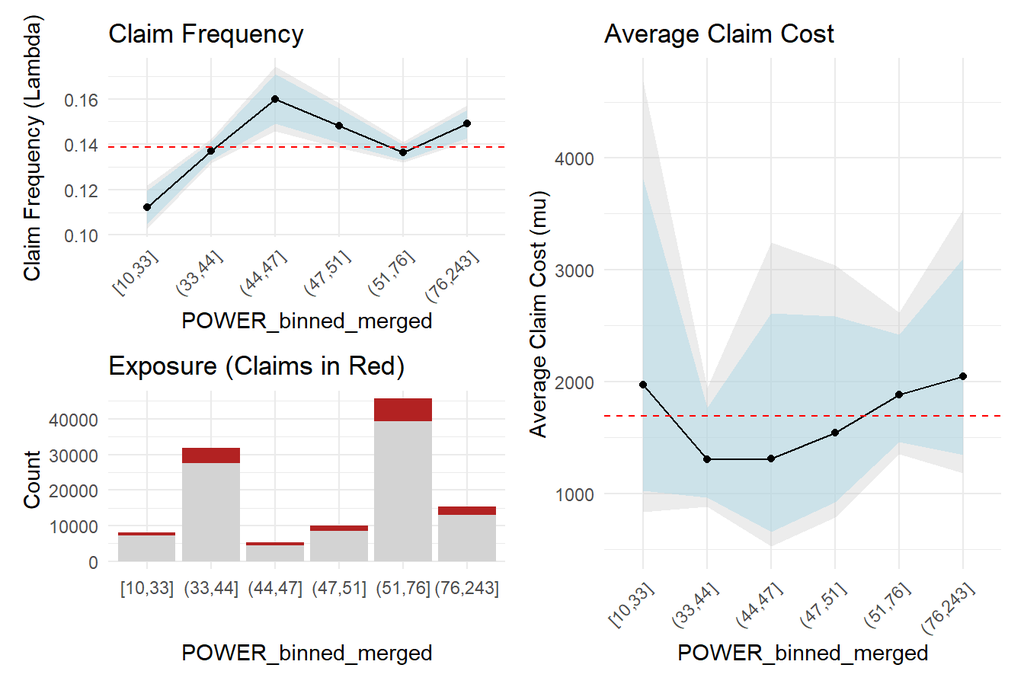

```r
data$POWER_binned_merged <- fct_collapse(
    data$POWER_binned,
    "(76,243]" = c("(76,83]", "(83,99]", "(99,243]")
)
m0 <- glm(NCLAIMS ~ offset(log(EXP)) + POWER_binned, data = data, family = poisson(link = "log"))
m1 <- glm(NCLAIMS ~ offset(log(EXP)) + POWER_binned_merged, data = data, family = poisson(link = "log"))
test_result <- anova(m0, m1, test = "Chisq")
pval <- test_result$`Pr(>Chi)`[2]

if(pval < 0.05) {
    cat(sprintf("Merging the last 3 bins of POWER_binned was not justified (p-value = %f).\n", pval))
    data$POWER_binned_merged <- NULL
} else {
    cat(sprintf("Merging the last 3 bins of POWER_binned was justified (p-value = %f).\n", pval))
    plot(plot_freq_sev(data, "POWER_binned_merged"))
}
```

The Data Exploration phase is now complete. We visually examined the frequency and severity of claims across different variables and their bins. We statistically tested whether some variables could be dropped and whether merging certain bins was justified, we concluded that:

- `USE` is not significant and should not be included in the model.
- The last 3 bins (“(66,68]”, “(68,71]”, “(71,95]”) of `AGEPH_binned` should be merged.
- The second and third bins (“(1,2]”, “(2,3]”) of `AGEC_binned` should not be merged.
- The last 3 bins (“(76,83]”, “(83,99]”, “(99,243]”) of `POWER_binned` should be merged.

Note that geospatial features such as `LONG`, `LAT`, `TOWN`, and `PC` where not included in the data exploration. We will address geospatial features in the feature engineering section - geospatial features. The raw continuous variables were not examined either. They will be analysed in the feature engineering section - polynomial features section.

## 3.3 Feature Engineering

Besides the existing features, we can create additional features to add information to our design matrix and potentially improve our models.

- **Geospatial Features**: We will take a theoretical detour to better understand how locations are classified in Belgium according to the `NIS code` nomenclature. Ideally, this hierarchical structure should be used as the basis of a credibility model for hierarchical features. This is outside the scope of this assignment. We will instead explain how a location can be represented as numerical or categorical and what it means in terms of interpretation. We will then use the NIS codes to fetch the Region linked to each location, retrieve the population density in the postcode and create a transformed municipality-level feature to capture biggest municipalities only.
- **Polynomial Features**: As we will see in the modelling section, adding polynomial features can be a good way to capture non-linear relationships in our GLM models. This is an intermediate step towards the smoothing functions of Generalized Additive Models (GAMs). We can test the first, second and third degree polynomial features for continuous variables to better understand their relationship with the target variables (frequency and severity). Note that this is less straighforward to explain to a customer. It is best used in technical premium modeling but should likely be removed from the commercial premium models.
- **Interaction Features**: All the analysis we have done so far has focused on individual features. The statistical modelling (GLM, GAM) will allow us to capture the controlled effects of the features. However, some interactions between features are not captured by linear terms alone. We can create interaction features to explicitly model these effects.

### 3.3.1 Geospatial Features

Location can be considered at multiple levels of granularity. In Belgium, the `National Institute of Statistics` provides a `NIS code` nomenclature that uniquely identifies each location at various granularities, from most specific to most general:

- `Statistical Sector`:(~20,000 sectors) that are granular enough to capture neighborhood variations within a postal code. This is typically interesting for sociodemographic (socioeconomic indexes, population density, etc.) analysis.
- `Postal Code (PC)`:(~600 codes) a more aggregated level, capturing aggregated characteristics. This is a more practical level for many analyses to avoid missing data issues and respecting privacy concerns on limited datasets.
- `Administrative Arrondissement`:(~40 arrondissements) this might be the less informative level for us as it is very aggregated but is not a political division yet.
- `Province`:(~10 provinces) the political implications should be considered at this level as provinces have a certain degree of autonomy. Note that Brussels-Capital does not have this level of granularity as it is a region.
- `Region`:(3 regions) the highest level of granularity, the biggest political and administrative decision-making occurs at this level. It captures a different kind of information compared to the more localized levels.

Choosing the best level of analysis is not an easy task. It first depends on data availability and portfolio size. For smaller portfolios or when data is sparse, higher-level aggregations like provinces will allow for more robust statistical analysis. Conversely, for larger portfolios with sufficient data, more granular levels like statistical sectors or postal codes will help better differentiate risk pockets.

Besides, granularities will often capture completly different underlying risk. Let’s clarify this with a climate risk example [^14] using different granularities.

- `Latitude` and `Longitude`: These **numerical** features simple indicate the point on a map. If we have a large enough geographical coverage, it will help us capture meteorological patterns. For **physical risks**, such as floods or storms, we understand that a northern country will face different risk (hail breaking the windhshield, floods damaging the cars parked outdoors) compared to a southern country where heatwaves can cause damage to tires and paintwork. In a single country such as Belgium, it won’t be very helpful as such but might capture other factors such as traffic density, urbanization, or quality of infrastructure. The `Statistical Sector` or `Postal Code` can also act as proxies for these underlying factors.
- `Regions`: The **categorical** features will capture administrative and political divisions, which can be important for understanding regional policies and regulations. When we look at **transition risk**, this becomes particularly relevant. For example, when the Brussels-Capital Region restricted the access to old diesel vehicles, this became stranded assets for owners of such vehicles within the region. Regions can take other decisions that impact risk exposure, such as subsidising electric vehicles, promoting public transportation, or offering advantageous schemes for company cars. This will play a role in the behavioral patterns and risk exposure of vehicle owners within the region.

We should not “choose” between granularities as they capture different underlying information. The credibility approach with hierarchical levels is a good way to account for many nested levels that would not yield stable estimates in a traditional model. However, we are working with a traditional GLM in this assignment and keeping all granularities gives a big risk of **near multicollinearity**. In our dataset, we already have the postcode (583 levels) and town (578 levels) which seem to capture the same underlying geographical information and the `LAT` and `LONG` features.

- To avoid redundancy, we will drop the `TOWN` feature and keep the `PC` which is part of the official NIS nomenclature.
- `LAT` and `LONG` will also be kept as numerical input for the smoothing functions we will use in the GAM models.
- To capture political and administrative underlying factors, we will add the `Regions` feature as a categorical variable.
- Finally, we will fetch the demographic density for each postcode which will serve as a proxy for urbanization and traffic exposure.

We expect higher frequency of claims and lower severity in areas with higher demographic density, as traffic congestion may lead to more minor accidents rather than severe ones. Conversely, we expect lower frequency and higher severity in more rural areas. It will be interesting to control the predictive power of postcode with demographic density to see if it has predictive power beyond what is captured by urbanization and traffic exposure.

#### 3.3.1.1 Dataset Enrichment

Before the enrichment, let us drop the `TOWN` feature as it is redundant but not perfecly aligned with the postcode, we’ll replace it with postcode labels.

```r
data <- data %>% select(-TOWN)
```

There are two main options for enriching our dataset with geographical information:

**Geospatial Enrichment**

- Geocode the `LAT` and `LONG` features to obtain precise geographical coordinates. We will use the Belgian Lambert 2008 (3812) projection[^15] to be in line with the NIS standards.
- Download the [shapefiles for Belgian administrative boundaries](https://statbel.fgov.be/en/open-data/statistical-sectors-2025).
- Perform spatial matching between the geocoded points and the administrative boundaries to enrich the dataset with region, postcode, and statistical sector information.

**Code Hierarchy Enrichment**

- We can take a shortcut by finding matching tables that link postcodes to refnis, and use the code to assign regions, avoiding the geocoding and spatial matching steps.
- Then we merge these tables with our dataset based on the postcode to enrich it with the corresponding region.

After this step, we can look for national statistics of population density for 1997 (year of the dataset) in each municipality and merge them with our dataset to further enrich it.

```r
conv <- read.csv("../data/postcode_refnis_conversion.csv", sep = ";") %>% data.frame()
refnis <- read.csv("../data/refnis_matching.csv", sep = ";") %>% data.frame()
pop <- read.csv("../data/pop_1997.csv", sep = ";") %>% data.frame() %>%
    mutate(NIS.code = as.integer(NIS.code)) %>%
    filter(!is.na(NIS.code) & NIS.code != "")

dup_conv <- conv[duplicated(conv$Postal.code), ]
if(nrow(dup_conv) > 0) {
    warning("There are duplicate postal codes in the conversion table.")
    conv %>% filter(Postal.code %in% dup_conv$Postal.code) %>% data.frame() %>%
    kable(booktabs = TRUE, width = 100, caption = "Duplicate Postal Codes in Conversion Table")
}
```

Duplicate Postal Codes in Conversion Table

| Postal.code | Refnis.code | Gemeentenaam | Nom.commune |
| --- | --- | --- | --- |
| 1040 | 21004 | Brussel | Bruxelles |
| 1040 | 21005 | Etterbeek | Etterbeek |
| 1050 | 21004 | Brussel | Bruxelles |
| 1050 | 21009 | Elsene | Ixelles |
| 1804 | 23088 | Vilvoorde | Vilvorde |
| 1804 | 23096 | Zemst | Zemst |

```r
dup_refnis <- refnis[duplicated(refnis$NIS_MUN), ]
if(nrow(dup_refnis) > 0) {
    warning("There are duplicate NIS_MUN codes in the refnis table.")
    refnis %>% filter(NIS_MUN %in% dup_refnis$NIS_MUN) %>% data.frame() %>%
    kable(booktabs = TRUE, width = 100, caption = "Duplicate NIS_MUN Codes in Refnis Table")
}

dup_pop <- pop[duplicated(pop$NIS.code), ]
if(nrow(dup_pop) > 0) {
    warning("There are duplicate NIS codes in the population table.")
    pop %>% filter(NIS.code %in% dup_pop$NIS.code) %>% data.frame() %>%
    kable(booktabs = TRUE, width = 100, caption = "Duplicate NIS Codes in Population Table")
}
```

Before proceeding with the matching, we need to make sure that our matching keys are unique. We see that in the conversion table, there are duplicate postal codes, 1040 and 1050 can also be matched to Bruxelles but the other matched provide more insight (Etterbeek and Ixelles). For the postcode 1804, Vilvoorde is the corresponding municipality with some overlap with nearby Zemst which we will drop.

```r
conv_matching <- conv %>% filter(!(
    (Postal.code == 1040 & Nom.commune == "Bruxelles") |
    (Postal.code == 1050 & Nom.commune == "Bruxelles") |
    (Postal.code == 1804 & Nom.commune == "Zemst")
))
if(any(duplicated(conv_matching$Postal.code))) {
    stop("There are still duplicate postal codes in the filtered conversion table.")
}

matched <- data %>% select(c("ID", "PC")) %>%
    mutate(PC = as.integer(as.character(PC))) %>%
    left_join(select(conv_matching, c("Postal.code","Refnis.code")), by = c("PC" = "Postal.code")) %>%
    left_join(select(refnis, c("NIS_MUN", "MUNICIPALITY", "REGION")), by = c("Refnis.code" = "NIS_MUN")) %>%
    left_join(select(pop, c("NIS.code", "Totaal")), by = c("Refnis.code" = "NIS.code")) %>%
    rename(
        REFNIS = Refnis.code,
        MUNICIPALITY = MUNICIPALITY,
        REGION = REGION,
        POPULATION = Totaal
    )

if(any(duplicated(matched$ID))) stop("There are duplicate IDs in the matched dataset.")
if(nrow(matched) != nrow(data)) stop("The number of matched rows does not match the original data.")

data_enriched <- data %>%
    left_join(select(matched, c("ID", "REFNIS", "MUNICIPALITY", "REGION", "POPULATION")), by = "ID")
data_enriched <- data_enriched %>%
    mutate(
        REFNIS = factor(REFNIS) %>% fct_infreq(),
        MUNICIPALITY = factor(MUNICIPALITY) %>% fct_infreq(),
        REGION = factor(REGION) %>% fct_infreq(),
        POPULATION = as.numeric(gsub("\\.", "", POPULATION)),
        POPULATION = ifelse(is.na(POPULATION), mean(POPULATION, na.rm = TRUE), POPULATION)
    )

if(nrow(data) != nrow(data_enriched)) stop("The number of rows in the enriched data does not match the original data.")
if(any(is.na(data_enriched$ID))) stop("There are missing IDs in the enriched data.")

summary(data_enriched %>% select(c("PC", "REFNIS", "MUNICIPALITY", "REGION", "POPULATION"))) %>%
kable(booktabs = TRUE, width = 100, caption = "Summary of Enriched Data")
```

Summary of Enriched Data

|  | PC | REFNIS | MUNICIPALITY | REGION | POPULATION |
| --- | --- | --- | --- | --- | --- |
|  | 6000 : 3992 | 52011 : 3992 | Charleroi : 3992 | RÉGION WALLONNE :62973 | Min. : 995 |
|  | 2000 : 3716 | 11002 : 3837 | Anvers : 3837 | RÉGION FLAMANDE :59750 | 1st Qu.: 13222 |
|  | 9000 : 2770 | 44021 : 2770 | Gand : 2770 | RÉGION DE BRUXELLES-CAPITALE: 7862 | Median : 24586 |
|  | 4000 : 2115 | 62063 : 2115 | Liège : 2115 | NA | Mean : 56488 |
|  | 7100 : 1806 | 58001 : 1806 | La Louvière: 1806 | NA | 3rd Qu.: 56488 |
|  | 7000 : 1649 | 53053 : 1649 | Mons : 1649 | NA | Max. :453030 |
|  | (Other):114537 | (Other):114416 | (Other) :114416 | NA | NA |

#### 3.3.1.2 Population Density

```r
baseline_pop <- qbinning(data_enriched, "POPULATION", "NCLAIMS", max_bins = 30)
result_pop <- iv_elbow(data_enriched, "POPULATION", "NCLAIMS", baseline_pop)
result_named_list[["POPULATION"]] <- result_pop
plot_iv_elbow(result_pop)
```

[interactive chart not shown]

Based on the elbow plot, we can look at the WoE and IV for 5, 6, 12 and 20 bins:

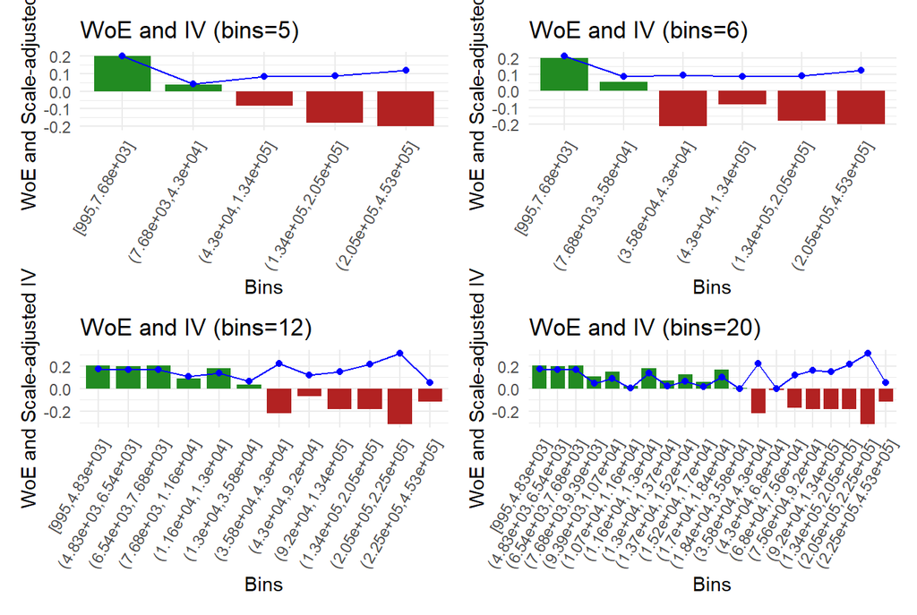

```r
plots_pop <- list()
for (i in c(5, 6, 12, 20)) {
    temp_bins_pop <- rebuild_bins(result_pop, i)
    woe_temp_pop <- woe_calc(data_enriched, x = "POPULATION", y = "NCLAIMS", bins = temp_bins_pop)
    plots_pop[[i]] <- plot_woe_iv(woe_temp_pop, interactive = FALSE)
}
(plots_pop[[5]] | plots_pop[[6]]) / (plots_pop[[12]] | plots_pop[[20]])
```

We see a linear diminution of the WoE as the population increases, indicating that higher population areas tend to have higher claim frequencies as we expected. The linear trend seems sufficiently captured with 5 bins. We’ll create the new binned variable with 5 levels.

```r
data_enriched$POPULATION_binned <- cut(
    data_enriched$POPULATION,
    breaks = rebuild_bins(result_pop, 5),
    include.lowest = TRUE,
    ordered_result = TRUE
)
n_bins_named_list[["POPULATION"]] <- 5
m0 <- glm(NCLAIMS ~ offset(log(EXP)), data = data_enriched, family = poisson(link = "log"))
m1 <- glm(NCLAIMS ~ POPULATION_binned + offset(log(EXP)), data = data_enriched, family = poisson(link = "log"))
chisq_result <- anova(m0, m1, test = "Chisq")
cat(sprintf("Is the effect of POPULATION_binned significant at 95%% confidence? %s", ifelse(chisq_result$`Pr(>Chi)`[2] < 0.05, "Yes", "No")))
```

```
Is the effect of POPULATION_binned significant at 95% confidence? Yes
```

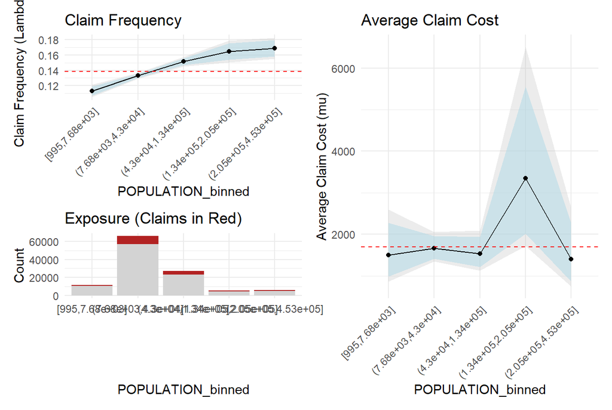

```r
plot_freq_sev(data_enriched, "POPULATION_binned")
```

The variable is significant at 95% confidence. We see that the 2 largest population bins have very similar claim frequencies, however, merging them would remove the distinction between these two bins that we see for the average claim cost.

#### 3.3.1.3 Regions

We will check the significance and claim frequency across regions

```r
m0 <- glm(NCLAIMS ~ offset(log(EXP)), data = data_enriched, family = poisson(link = "log"))
m1 <- glm(NCLAIMS ~ offset(log(EXP)) + REGION, data = data_enriched, family = poisson(link = "log"))
    test_result <- anova(m0, m1, test = "Chisq")
    cat(sprintf("Is variable %s significant? %s\n", "REGION", ifelse(test_result$`Pr(>Chi)`[2] < test_level, "Yes", "No")))
```

```
Is variable REGION significant? Yes
```

[figure not shown]

```r
plot_freq_sev(data_enriched, "REGION")
```

It is clear that the Brussels region has a distinct claim frequency and severity pattern compared to the other regions. It is interesting to note that the frequency is higher while the severity is lower, which aligns with our hypothesis about urban areas. We’ll test if it makes sense to keep the Walloon and Flemish regions separated as well or not (as before, the test is made on the claim frequency using a chi-squared test).

```r
merged_regions <- fct_collapse(
    data_enriched$REGION,
    "Brussels" = c("RÉGION DE BRUXELLES-CAPITALE"),
    "Others" = c("RÉGION WALLONNE", "RÉGION FLAMANDE"),
)
data_enriched$REGION_merged <- merged_regions
m0 <- glm(NCLAIMS ~ offset(log(EXP)) + REGION, data = data_enriched, family = poisson(link = "log"))
m1 <- glm(NCLAIMS ~ offset(log(EXP)) + REGION_merged, data = data_enriched, family = poisson(link = "log"))
test_result <- anova(m0, m1, test = "Chisq")
cat(sprintf("Was it justified to merge the REGION bins? %s", ifelse(test_result$`Pr(>Chi)`[2] < test_level, "No", "Yes")))
```

```
Was it justified to merge the REGION bins? Yes
```

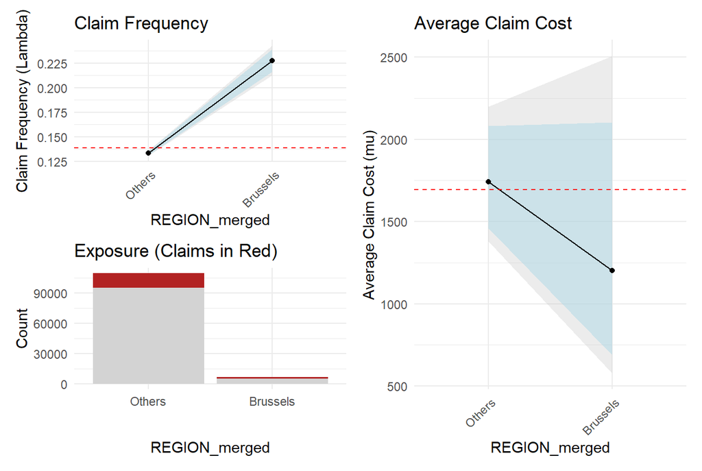

```r
plot_freq_sev(data_enriched, "REGION_merged")
```

We see that despite a much lower exposure in Brussels, the claim frequency is significantly higher from the other regions. The severity, although not significantly because of high variability, appears to be lower in Brussels compared to the other regions. This confirms our hypothesis that urban areas, such as Brussels, tend to have a higher claim frequency compared to less densely populated regions but that these accidents tend to have a lower severity:

```r
urb_rur_comp <- data_enriched %>%
    group_by(REGION_merged) %>%
    summarise(
        total_exposure = sum(EXP),
        total_claims = sum(NCLAIMS),
        total_claim_amount = sum(AMOUNT),
        frequency = total_claims / total_exposure,
        severity = total_claim_amount / total_claims,
        expected_claims = frequency * severity
    ) %>%
    arrange(desc(frequency))
urb_rur_comp %>%
    kable(
        caption = "Expected claims by merged region\nSplit by frequency and severity",
        align = "l", booktabs = TRUE
    )
```

Expected claims by merged region Split by frequency and severity

| REGION_merged | total_exposure | total_claims | total_claim_amount | frequency | severity | expected_claims |
| --- | --- | --- | --- | --- | --- | --- |
| Brussels | 6482.844 | 1477 | 1776783 | 0.2278321 | 1202.968 | 274.0746 |
| Others | 109723.584 | 14632 | 25498069 | 0.1333533 | 1742.624 | 232.3846 |

With this quick descriptive analysis, we can confirm that in our sample:

- The claim frequency is higher in urban areas like Brussels compared to other regions (factor 1.7084852)
- The claim severity is lower in urban areas like Brussels compared to other regions (factor 0.6903198)
- The frequency effect outweighs the severity effect in determining the expected claims between urban and other regions (factor 1.1794012)

We expect to see similar effects for other granularities, such as municipalities, where urban areas may exhibit higher claim frequencies but lower severities compared to less densely populated areas.

#### 3.3.1.4 Municipalities

There are far too many municipalities to use it as a simple categorical variable in our models. Hierachical credibility are out of scope. We can thus focus on the n largest municipalities by exposure and group the remaining ones into an “Other” category.

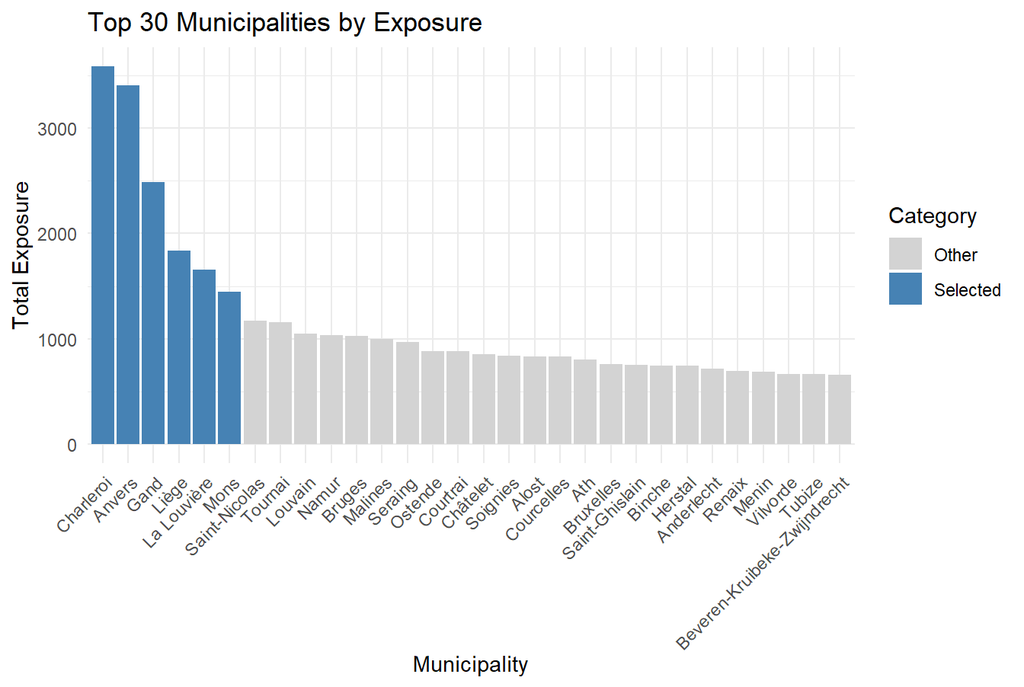

```r
data_enriched %>%
    group_by(MUNICIPALITY) %>%
    summarise(
        total_exposure = sum(EXP)
    ) %>%
    arrange(desc(total_exposure)) %>% head(n=30) %>%
    mutate(category = ifelse(row_number() <= 6, "Selected", "Other")) %>%
    ggplot(aes(x = reorder(MUNICIPALITY, -total_exposure), y = total_exposure, fill = category)) +
    geom_bar(stat = "identity") +
    scale_fill_manual(values = c("Selected" = "steelblue", "Other" = "lightgrey")) +
    labs(x = "Municipality", y = "Total Exposure", fill = "Category", title = "Top 30 Municipalities by Exposure") +
    theme_minimal() +
    theme(axis.text.x = element_text(angle = 45, hjust = 1))
```

We can focus on the 6 largest municipalities by exposure before the exposure distribution flattens out.

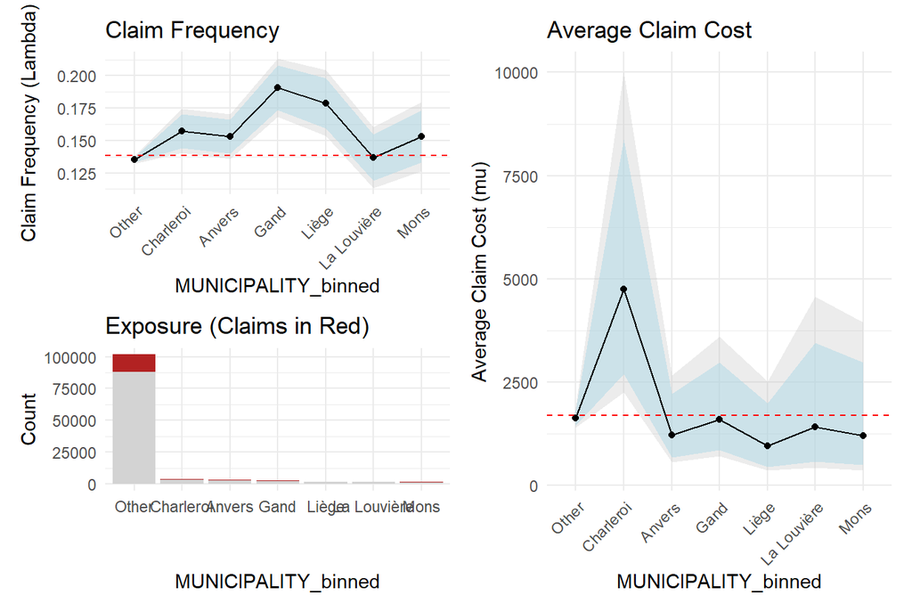

```r
exp_breakpoint <- data_enriched %>%
    group_by(MUNICIPALITY) %>%
    summarise(
        total_exposure = sum(EXP)
    ) %>%
    arrange(desc(total_exposure)) %>%
    head(n=6)
data_enriched$MUNICIPALITY_binned <- ifelse(data_enriched$MUNICIPALITY %in% exp_breakpoint$MUNICIPALITY, as.character(data_enriched$MUNICIPALITY), "Other")
data_enriched$MUNICIPALITY_binned <- factor(data_enriched$MUNICIPALITY_binned) %>% fct_infreq()

plot_freq_sev(data_enriched, "MUNICIPALITY_binned")
```

```r
m0 <- glm(NCLAIMS ~ offset(log(EXP)), data = data_enriched, family = poisson(link = "log"))
m1 <- glm(NCLAIMS ~ MUNICIPALITY_binned + offset(log(EXP)), data = data_enriched, family = poisson(link = "log"))
results <- anova(m0, m1, test = "Chisq")
cat(sprintf("Is variable %s significant? %s\n", "MUNICIPALITY_binned", ifelse(results$`Pr(>Chi)`[2] < test_level, "Yes", "No")))
```

```
Is variable MUNICIPALITY_binned significant? Yes
```

We now have a binned version of the MUNICIPALITY variable which is significant and usable in our model. Of course, the exposure is limited even in the bigger municipalities and that causes some variability in the frequency estimates. However, for the sake of interpretation, we’ll keep the cities separated even though Charleroi and Antwerp are similar in terms of frequency and so are Gand and Liège. We seem to capture a similar phenomenon with cities having a higher claim frequency compared to smaller municipalities even if the effect is less clear than for the regions. What is also striking is that average claim cost is much higher in Charleroi than anywhere else.

```r
data_enriched %>%
    group_by(MUNICIPALITY_binned) %>%
    summarise(
        total_claims = sum(NCLAIMS),
        total_exposure = sum(EXP),
        total_claim_amount = sum(AMOUNT),
        frequency = total_claims / total_exposure,
        severity = total_claim_amount / total_claims,
        expected_claims = frequency * severity
    ) %>%
    arrange(desc(frequency)) %>%
    kable(
        caption = "Expected claims by municipality\nSplit by frequency and severity",,
        align = "l", booktabs = TRUE
    )
```

Expected claims by municipality Split by frequency and severity

| MUNICIPALITY_binned | total_claims | total_exposure | total_claim_amount | frequency | severity | expected_claims |
| --- | --- | --- | --- | --- | --- | --- |
| Gand | 474 | 2484.419 | 756248.0 | 0.1907891 | 1595.4599 | 304.3963 |
| Liège | 329 | 1838.449 | 311331.2 | 0.1789552 | 946.2954 | 169.3445 |
| Charleroi | 565 | 3590.329 | 2681716.8 | 0.1573672 | 4746.4015 | 746.9279 |
| Mons | 222 | 1449.710 | 266246.7 | 0.1531341 | 1199.3094 | 183.6552 |
| Anvers | 521 | 3405.019 | 637351.8 | 0.1530094 | 1223.3240 | 187.1801 |
| La Louvière | 227 | 1658.945 | 319355.9 | 0.1368339 | 1406.8543 | 192.5054 |
| Other | 13771 | 101779.556 | 22302602.0 | 0.1353022 | 1619.5340 | 219.1265 |

Even if some cities follow the high frequency, low severity pattern, we do find outliers such as Charleroi where the severity is unusually high or Liège where it falls unusually low. We then seem to capture something more than the simple urban-rural divide which justifies keeping the `MUNICIPALITY_binned` variable in our model.

### 3.3.2 Polynomial Features

For the five numerical variables, we will consider the polynomial features up to the third degree to capture potential non-linear relationships with the response variable. This is an intermediate step towards the GAM models where we will explicitly model non-linear effects. Note that: - We will use Pearson correlation (continuous variables) instead of Spearman correlation because the rank-rank approach won’t help us differentiate between the polynomial features of the same positive variable (ranks are maintained). - We will look at the p-values of the correlation tests instead of the correlation coefficients themselves to assess the significance of the relationships. - For the correlation with average claim amount (`AVG`), we will only consider the claims where `NCLAIMS` is greater than zero. - Orthogonal polynomial features will be considered separately to avoid multicollinearity issues inherent in raw polynomial features. - To compute orthogonal polynomial features, we will filter out the NA values from the data.

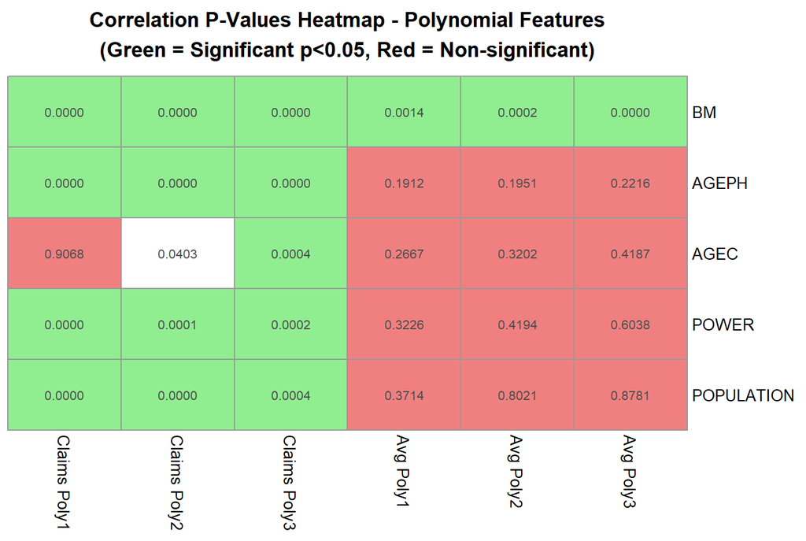

```r
numerical_continuous <- c("BM", "AGEPH", "AGEC", "POWER", "POPULATION")

polynomial_features <- lapply(numerical_continuous, function(var) {
    poly(data_enriched[[var]], degree = 3, raw = TRUE)
})
names(polynomial_features) <- numerical_continuous
correlation_matrix <- data.frame(
    matrix(NA, nrow = length(numerical_continuous), ncol = 6)
)
rownames(correlation_matrix) <- numerical_continuous
colnames(correlation_matrix) <- c(
    "Claims Poly1", "Claims Poly2", "Claims Poly3",
    "Avg Poly1", "Avg Poly2", "Avg Poly3")

for (var in numerical_continuous) {
    poly_values <- polynomial_features[[var]]
    for (j in 1:3) {
        correlation_matrix[var, j] <- cor.test(data_enriched[["NCLAIMS"]], poly_values[, j], method = "pearson")$p.value
        claims_only_avg <- data_enriched[["AVG"]][data_enriched[["NCLAIMS"]] > 0]
        claims_only_poly_values <- poly_values[data_enriched[["NCLAIMS"]] > 0, j]
        correlation_matrix[var, j + 3] <- cor.test(claims_only_avg, claims_only_poly_values, method = "pearson")$p.value
    }
}

pheatmap(correlation_matrix,
    main = "Correlation P-Values Heatmap - Polynomial Features\n(Green = Significant p<0.05, Red = Non-significant)",
    display_numbers = TRUE,
    number_format = "%.4f",
    breaks = c(0, 0.01, 0.05, 1),
    color = c("lightgreen", "white", "lightcoral"),
    legend = FALSE,
    cluster_rows = FALSE,
    cluster_cols = FALSE
)
```

We notice that the correllations between the polynomial features of a same variable are similar, this is foreseeable given that higher-degree polynomials are derived from the lower-degree ones. We are here exposed to multicollinearity issues. A solution is to check the **orthogonal polynomial features** instead of the raw ones, as they are uncorrelated by construction. This also enables us to differentiate the individual contributions of each polynomial term more clearly in the modeling process (linear, quadratic, cubic).

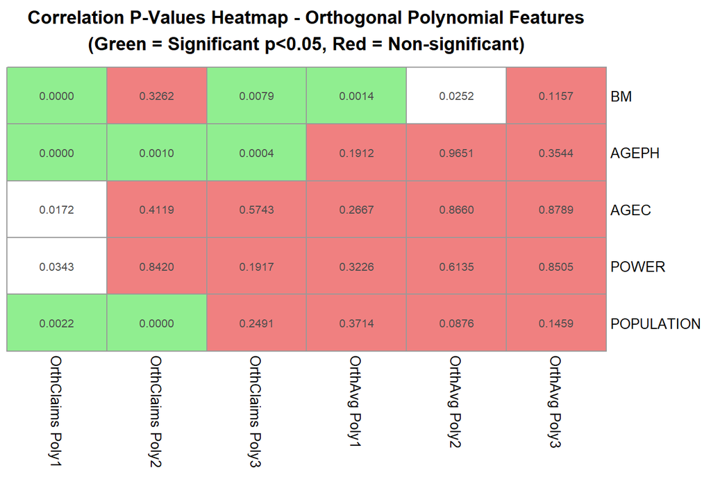

```r
no_na <- na.omit(data_enriched)
orthogonal_polynomial_features <- lapply(numerical_continuous, function(var) {
    poly(no_na[[var]], degree = 3, raw = FALSE)
})
names(orthogonal_polynomial_features) <- numerical_continuous
orth_correlation_matrix <- data.frame(
    matrix(NA, nrow = length(numerical_continuous), ncol = 6)
)
rownames(orth_correlation_matrix) <- numerical_continuous
colnames(orth_correlation_matrix) <- c(
    "OrthClaims Poly1", "OrthClaims Poly2", "OrthClaims Poly3",
    "OrthAvg Poly1", "OrthAvg Poly2", "OrthAvg Poly3")

for (var in numerical_continuous) {
    poly_values <- orthogonal_polynomial_features[[var]]
    for (j in 1:3) {
        orth_correlation_matrix[var, j] <- cor.test(no_na[["NCLAIMS"]], poly_values[, j], method = "pearson")$p.value
        claims_only_avg <- no_na[["AVG"]][no_na[["NCLAIMS"]] > 0]
        claims_only_poly_values <- poly_values[no_na[["NCLAIMS"]] > 0, j]
        orth_correlation_matrix[var, j + 3] <- cor.test(claims_only_avg, claims_only_poly_values, method = "pearson")$p.value
    }
}

pheatmap(orth_correlation_matrix,
    main = "Correlation P-Values Heatmap - Orthogonal Polynomial Features\n(Green = Significant p<0.05, Red = Non-significant)",
    display_numbers = TRUE,
    number_format = "%.4f",
    breaks = c(0, 0.01, 0.05, 1),
    color = c("lightgreen", "white", "lightcoral"),
    legend = FALSE,
    cluster_rows = FALSE,
    cluster_cols = FALSE
)
```

From this orthogonal polynomial feature exploration we can conclude that:

- Polynomial features are more significantly correlated with the number of claims (`NCLAIMS`) than with the average claim amount (`AVG`) which can simply be due to lesser observations for the latter.
- Orthogonal polynomial features help assess whether each polynomial term contributes significantly to the relationship with the target variables, without being confounded by multicollinearity. This will serve as benchmark to the smoothing functions in the GAM models.

In conclusion, polynomials are a way to capture non-linear relationships. However, the incremental effect of these polynomial terms is still fixed in a GLM. We therefore prefer working with binned features rather than relying solely on polynomial terms. We will nevertheless see if the smoothing functions of the GAM models confirm the conclusions drawn from our exploratory analysis.

### 3.3.3 Interaction Features

Interactions are usually added as a result of business knowledge. In our case, we know from a theorical background that the age of the policyholder interacts with the power of the car. We can add this interaction effect and test its significance in our models. Instead of manually testing all possible combinations. We’ll use a decision tree approach which nature is to look for interactions and splits that best explain the variability in the target variable. With a shallow decision tree (depth of 3), we can identify the most relevant interactions without overfitting the data. Watch out the decision trees are not robusts and can be sensitive to small changes in the data. We’ll do a 10-fold cross-validation to mitigate this issue.

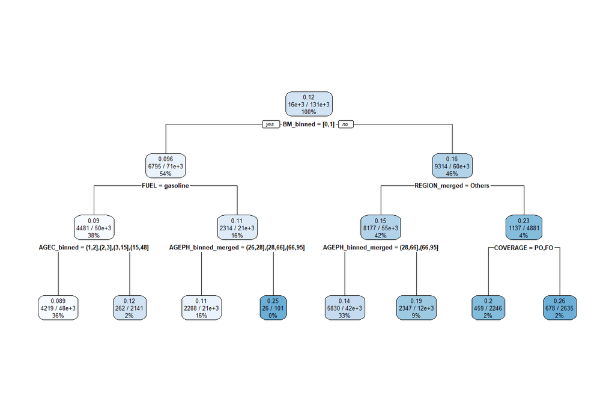

```r
tree_model <- rpart(
    NCLAIMS ~ COVERAGE + FUEL + FLEET + SEX + # Categorical features
    BM_binned + AGEPH_binned_merged + AGEC_binned + POWER_binned_merged + # Binned numerical features
    POPULATION_binned + REGION_merged + MUNICIPALITY_binned, # Enriched features
    data = data_enriched,
    method = "poisson",
    control = rpart.control(maxdepth = 3, xval = 10, cp = 0)
)
rpart.plot(tree_model)
```

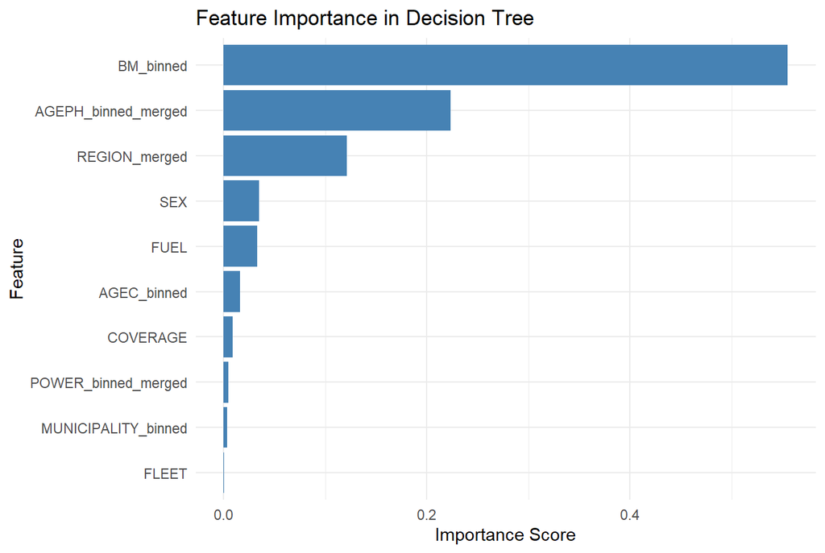

```r
importance_df <- data.frame(
    feature = names(tree_model$variable.importance),
    importance = tree_model$variable.importance %>% `/`(sum(.))
)
importance_df <- importance_df %>% arrange(desc(importance))

ggplot(importance_df, aes(x = reorder(feature, importance), y = importance)) +
    geom_bar(stat = "identity", fill = "steelblue") +
    coord_flip() +
    labs(title = "Feature Importance in Decision Tree",
            x = "Feature",
            y = "Importance Score") +
    theme_minimal()
```

Based on this machine learning approach, we can identify both specific interactions and the most important features that influence the target variable. When adding interaction terms to our models, we can thus consider:

**Specific Interactions:** representing the two first splits identified by the decision tree.

- `BM_binned.[0,1]` x `FUEL.gasoline`
- `BM_binned.[0,1]` x `!FUEL.gasoline`
- `!BM_binned.[0,1]` x `REGION_merged.Others`: will not add it as it is captured below already
- `!BM_binned.[0,1]` x `!REGION_merged.Others`: will not add it as it is captured below already

```r
data_enriched <- data_enriched %>%
    mutate(
        BM_01_FUEL_gasoline = BM_binned == "[0,1]" & FUEL == "gasoline",
        BM_01_FUEL_not_gasoline = BM_binned == "[0,1]" & FUEL != "gasoline"
    )
```

This concludes the feature engineering and more generally the data preparation phase. We now have a set of enriched, transformed, binned, and merged features ready for the modelling phase. We will start the next section by listing this set of variables and looking at the reference class.

# 4 Frequency Modeling

Now that we have explored, transformed, and enriched our data. We are ready to proceed with the modelling phase. As described in the Approach section of the Introduction, we will go from the null model (with the offset only) towards more complex models by gradually incorporating features and keeping the significant ones. Below is a list of the variables and their 5 first levels per layer of complexity.

```r
# Clean intermediary objects not used for modelling
functions <- ls()[sapply(ls(), function(x) is.function(get(x)))]
rm(list = setdiff(ls(), c(
    "data", "data_enriched", "holdout", "mtpl_be",
    "conv_matching", "refnis", "pop",
    "result_named_list", "n_bins_named_list",
    functions)))
cat(sprintf("Remaining objects and functions: %s", paste(ls(), collapse = ", ")))
```

```
Remaining objects and functions: assert_ref_level, conv_matching, data, data_enriched, holdout, iv_elbow, mtpl_be, n_bins_named_list, plot_avg_claim_cost, plot_claim_freq, plot_freq_sev, plot_iv_elbow, plot_woe_iv, pop, qbinning, rebuild_bins, refnis, result_named_list, woe_calc
```

```r
# Save remaining objects for modelling
save(list = ls(), file = "../data/modelling_objects.RData")
```

```r
load("../data/modelling_objects.RData")

original_categorical_features <- c("COVERAGE", "FUEL", "FLEET", "SEX")
continuous_features <- c("BM", "AGEPH", "AGEC", "POWER")
binned_continuous_features <- c("BM_binned", "AGEPH_binned_merged", "AGEC_binned", "POWER_binned_merged")
enriched_features <- c("REGION_merged", "MUNICIPALITY_binned", "POPULATION")
binned_enriched_features <- c("REGION_merged", "MUNICIPALITY_binned", "POPULATION_binned")
interaction_features <- c("BM_01_FUEL_gasoline", "BM_01_FUEL_not_gasoline", "BM_binned:AGEPH_binned_merged", "REGION_merged:AGEPH_binned_merged", "BM_binned:REGION_merged")

levels_named_list <- list()
for (col in c(original_categorical_features, binned_continuous_features, binned_enriched_features)) {
    if (!col %in% colnames(data_enriched)) {stop(sprintf("Column %s is missing from data_enriched", col))}
    levels_named_list[[col]] <- levels(data_enriched[[col]])
}
```

**Original Categorical Features:** Note that `USE` was excluded because it was not statistically significant in preliminary analyses. The variables for the first set of predictors are:

```r
for (col in original_categorical_features) {
    cat(sprintf("Levels for %s: %s\n", col, paste(head(levels_named_list[[col]],5), collapse = ", ")))
}
```

```
Levels for COVERAGE: TPL, PO, FO
Levels for FUEL: gasoline, diesel
Levels for FLEET: N, Y
Levels for SEX: male, female
```

The reference levels will thus represent male policyholders with a third-party liability coverage only for a gasoline-fueled vehicle which is not part of a fleet.

**Continuous Features:** The continuous features as such will be included in the GAM models only. We binned and merged them into categorical variables for the GLM modelling.

```r
for (col in binned_continuous_features) {
    cat(sprintf("Levels for %s: %s\n", col, paste(head(levels_named_list[[col]],5), collapse = ", ")))
}
```

```
Levels for BM_binned: [0,1], (1,11], (11,22]
Levels for AGEPH_binned_merged: [18,24], (24,26], (26,28], (28,66], (66,95]
Levels for AGEC_binned: [0,1], (1,2], (2,3], (3,15], (15,48]
Levels for POWER_binned_merged: [10,33], (33,44], (44,47], (47,51], (51,76]
```

The reference levels are here defined by the first level of each binned continuous feature. We therefore have a policyholder between 18 and 24 years old with a new car (less than 1 year old) of 10 to 33 kilowatts of power and a bonus-malus score of 0.

**Enriched Features:** Based on geospation information, we have created, binned and merged both categorical and continuous features to capture urban/rural distinctions and municipality-level characteristics.

```r
for (col in binned_enriched_features) {
    cat(sprintf("Levels for %s: %s\n", col, paste(head(levels_named_list[[col]],5), collapse = ", ")))
}
```

```
Levels for REGION_merged: Others, Brussels
Levels for MUNICIPALITY_binned: Other, Charleroi, Anvers, Gand, Liège
Levels for POPULATION_binned: [995,7.68e+03], (7.68e+03,4.3e+04], (4.3e+04,1.34e+05], (1.34e+05,2.05e+05], (2.05e+05,4.53e+05]
```

The reference for these enriched features is a policyholder living in a small municipality (995 to 7680 inhabitants) outside of Brussels and the other main urban areas.

**Interaction Features:** We have also created specific and variable interaction features based on expert knowledge and the decision tree analysis.

- `POWER_binned_merged` x `AGEPH_binned_merged`: expert knowledge
- `BM_01_FUEL_gasoline`: specific interaction based on decision tree analysis
- `BM_01_FUEL_not_gasoline`: specific interaction based on decision tree analysis
- `BM_binned` x `AGEPH_binned_merged`: variable interaction based on feature importance
- `REGION_merged` x `AGEPH_binned_merged`: variable interaction based on feature importance
- `BM_binned` x `REGION_merged`: variable interaction based on feature importance

**Polynomial Features:** We also considered raw and orthogonal polynomial features for the continuous variables to capture potential non-linear relationships in the GAM models. We decided not to include them in the GLM models for the sake of model simplicity and interpretability. These polynomial effects will be naturally captured in the GAM models through the smooth functions. We will then be able to see whether the GAM results confirm our exploratory analysis.

## 4.1 Validation Framework

The modelling exercise will be conducted on our training dataset, while keeping the holdout set separate for final model validation. In this section, we will create a workflow that encompasses both data preparation and model selection steps (including cross-validation).

- **Data Preparation**: starting from the enriched dataset, applying necessary transformations as described in the data preparation section.
- **Performance Evaluation**: the correct performance metrics need to be optimized for in order to pick the best model and avoid overfitting.
- **Model Workflow**: the complete modeling workflow will then be specified separately for frequence and severity and for GLM and GAM models in the next sections.

### 4.1.1 Data Preparation Workflow

The preparation recipe uses `step_mutate()` to bin continuous variables, merge factor levels, and create the specific interaction indicators. The saved `levels_named_list` defines the complete factor order. Then `step_relevel()` explicitly sets each reference level. Bin boundaries and levels remain fixed at their previously selected values when baking new data, which need not contain observations in every bin. Geographic enrichment remains a separate join before the recipe.

```r
# Data enrichment

data_enrichment <- function(input_data) {
    if (!("PC" %in% colnames(input_data))) {stop("PC column is missing from raw_data")}
    if (!("ID" %in% colnames(input_data))) {stop("ID column is missing from raw_data")}
    if (!exists("conv_matching")) {stop("conv_matching object is missing")}
    if (!exists("refnis")) {stop("refnis object is missing")}
    if (!exists("pop")) {stop("pop object is missing")}
    output_data <- input_data %>%
        mutate(TEMP_PC = as.integer(PC)) %>%
        left_join(select(conv_matching, c("Postal.code","Refnis.code")), by = c("TEMP_PC" = "Postal.code")) %>%
        left_join(select(refnis, c("NIS_MUN", "MUNICIPALITY", "REGION")), by = c("Refnis.code" = "NIS_MUN")) %>%
        left_join(select(pop, c("NIS.code", "Totaal")), by = c("Refnis.code" = "NIS.code")) %>%
        rename(
            REFNIS = Refnis.code,
            MUNICIPALITY = MUNICIPALITY,
            REGION = REGION,
            POPULATION = Totaal
        ) %>%
        select(-TEMP_PC) %>%
        mutate(
            POPULATION = as.numeric(gsub("\\.", "", POPULATION)),
        ) %>%
        mutate(
            POPULATION = ifelse(is.na(POPULATION), mean(POPULATION, na.rm = TRUE), POPULATION)
        )
    if (any(duplicated(output_data$ID))) {stop("Duplicated IDs found in enriched_data")}
    if (nrow(output_data) != nrow(input_data)) {stop("Row count mismatch between enriched_data and raw_data")}
    return(output_data)
}

# Preparation recipe

data_preparation_recipe <- function(input_data) {
    if (!exists("original_categorical_features")) {stop("original_categorical_features object is missing")}
    if (!exists("levels_named_list")) {stop("levels_named_list object is missing")}
    if (!exists("result_named_list")) {stop("result_named_list object is missing")}
    if (!exists("n_bins_named_list")) {stop("n_bins_named_list object is missing")}
    if (!exists("binned_continuous_features")) {stop("binned_continuous_features object is missing")}
    if (!exists("binned_enriched_features")) {stop("binned_enriched_features object is missing")}

    # Ensure all required columns are present in the input data
    factor_features <- c(original_categorical_features, binned_continuous_features)
    base_features <- unique(gsub("_binned|_merged", "", binned_continuous_features))
    required_columns <- c(original_categorical_features, base_features)
    missing_columns <- setdiff(required_columns, colnames(input_data))
    if (length(missing_columns) > 0) {
        stop(sprintf("Columns missing from input_data: %s", paste(missing_columns, collapse = ", ")))
    }

    # Set all original categorical features as factors
    rec <- recipe(~ ., data = input_data, strings_as_factors = FALSE) %>%
        step_mutate(
            across(all_of(!!original_categorical_features), as.factor)
        )

    # Bin the continuous features
    for (col in c(base_features, "POPULATION")) {
        n_bins <- n_bins_named_list[[col]]
        if (is.null(result_named_list[[col]]) || is.null(n_bins)) {
            stop(sprintf("Binning configuration is missing for column %s", col))
        }
        bins <- rebuild_bins(result_named_list[[col]], n_bins)
        if (length(bins) != n_bins + 1 || anyNA(bins) || any(diff(bins) <= 0)) {
            stop(sprintf("Invalid bin boundaries for column %s", col))
        }
        rec <- rec %>%
            step_mutate(
                !!paste0(col, "_binned") := cut(
                    !!rlang::sym(col), breaks = !!bins,
                    ordered_result = TRUE, include.lowest = TRUE
                )
            )
    }

    # Merge specific binned categories into broader categories
    rec <- rec %>%
        step_mutate(
            AGEPH_binned_merged = fct_collapse(
                AGEPH_binned, "(66,95]" = c("(66,68]", "(68,71]", "(71,95]")
            ),
            POWER_binned_merged = fct_collapse(
                POWER_binned, "(76,243]" = c("(76,83]", "(83,99]", "(99,243]")
            ),
            REGION_merged = fct_collapse(
                fct_expand(
                    as.factor(REGION), "RÉGION DE BRUXELLES-CAPITALE",
                    "RÉGION WALLONNE", "RÉGION FLAMANDE"
                ),
                "Brussels" = "RÉGION DE BRUXELLES-CAPITALE",
                "Others" = c("RÉGION WALLONNE", "RÉGION FLAMANDE")
            ),
            MUNICIPALITY_binned = factor(ifelse(
                MUNICIPALITY %in% !!levels_named_list[["MUNICIPALITY_binned"]],
                as.character(MUNICIPALITY), "Other"
            ))
        )

    # Set factor levels based on predefined levels_named_list and ensure they are unordered and with the correct reference level
    for (col in c(factor_features, "REGION_merged", "MUNICIPALITY_binned", "POPULATION_binned")) {
        feature_levels <- levels_named_list[[col]]
        if (is.null(feature_levels) || length(feature_levels) == 0) {
            stop(sprintf("Factor levels are missing for column %s", col))
        }
        factor_expression <- rlang::expr(factor(
            !!rlang::sym(col), levels = !!feature_levels, ordered = FALSE
        ))
        rec <- rec %>%
            step_mutate(!!!setNames(list(factor_expression), col)) %>%
            step_relevel(!!rlang::sym(col), ref_level = feature_levels[1])
    }

    # Add the two specific in
    rec <- rec %>%
        step_mutate(
            BM_01_FUEL_gasoline = BM_binned == "[0,1]" & FUEL == "gasoline",
            BM_01_FUEL_not_gasoline = BM_binned == "[0,1]" & FUEL != "gasoline"
        ) %>% prep()
    return(rec)
}

data_preparation_workflow <- function(input_data) {
    enriched_data <- data_enrichment(input_data)
    prepared_recipe <- data_preparation_recipe(enriched_data)
    output_data <- bake(prepared_recipe, new_data = enriched_data)
    return(output_data)
}
```

```r
test_data <- mtpl_be %>%
    filter(ID %in% data$ID) %>%
    data_preparation_workflow()

# Set ordered factors for binned continuous features to unordered
for (col in names(levels_named_list)) {
    data_enriched[[col]] <- factor(data_enriched[[col]], levels = levels_named_list[[col]], ordered = FALSE)
}

prepared_features <- unique(c(
    original_categorical_features, binned_continuous_features,
    enriched_features, binned_enriched_features,
    "BM_01_FUEL_gasoline", "BM_01_FUEL_not_gasoline"
))
for (col in prepared_features) {
    if (!col %in% colnames(test_data)) {
        stop(paste("Column", col, "is missing from test_data"))
    }
    if (!identical(test_data[[col]], data_enriched[[col]])) {
        stop(paste("Column", col, "does not match the enriched data"))
    }
}

cat(sprintf("All columns in test_data match the enriched data.\n(%s)", paste(c(original_categorical_features, binned_continuous_features, enriched_features), collapse = ", ")))
```

```
All columns in test_data match the enriched data.
(COVERAGE, FUEL, FLEET, SEX, BM_binned, AGEPH_binned_merged, AGEC_binned, POWER_binned_merged, REGION_merged, MUNICIPALITY_binned, POPULATION)
```

The preparation workflow works as expected and returns the same dataset as the one obtained throught data preparation. As this data transformation is the base for all subsequent modeling steps, we apply it once and we will reuse the prepared data throughout the analysis.

### 4.1.2 Performance Evaluation

To robustly evaluate the performance of our models, we will use a 5-fold cross-validation approach. This means that 5 samples will be created from the training data (with the number of claims as evenly distributed as possible across the folds). Then, for each of the five folds, one fold will be used as the validation set while the remaining four folds will be used as the training set. The performance metrics will then be computed for slight variations in the training and validation sets, providing a more robust estimate of model performance.

More specifically, we will look at two different cross-validation metrics: the log-loss and the (decomposed) prediction error.

1. Cross-Validated `Log-loss`

The log-loss is a measure based on the likelihood of the observed data given the predicted probabilities. The negative mean log-likelihood is used as the loss function. Note that the likelihood function depends on the assumed distribution poisson(log) or gamma(log)). For our frequency model, which assumes a Poisson distribution with a log link, the log-loss will then be:

$$\text{Log-loss} = -\frac{1}{n}
\sum_{i=1}^{n} \log \left( P(Y_i \mid \hat{\lambda}_i) \right)$$
where $Y_i$ is the observed number of claims for the $i$-th observation, and $\hat{\lambda}_i$ is the predicted mean from the Poisson model.

The function `dpois` in R will be used with `NCLAIMS` as the observed values and the predicted mean from the Poisson model as the lambda parameter. We’ll use log=TRUE to get the log-probabilities and be able to average them and then take the negative to compute the log-loss.

2. Cross-Validated `Prediction error`

The prediction error is a measure of the difference between the observed and predicted values for new data points that can be split between the training error and the optimism (difference between training and prediction error which can be seen as a complexity penalty):

$$\mathbb{E}[(Y_i^{\text{new}} -
\hat{Y}_i)^2] = \mathbb{E}[(Y_i - \hat{Y}_i)^2] + 2 Cov(Y_i,
\hat{Y}_i)$$

The training error can be replaced by the deviance $D$, which measures the goodness of fit of the model to the training data. The optimism term $2 Cov(Y_i, \hat{Y}_i)$ can be approximated by the penalty term $\frac{2(p+1)}{n}$, where $p$ is the number of parameters and $n$ is the sample size.

$$\text{Prediction error} = D +
\frac{2(p+1)}{n}$$

Therefore, the sum of prediction errors across all observations can be expressed as:

$$\text{Total Prediction Error} =
\sum_{i=1}^{n} \left( D_i + \frac{2(p+1)}{n} \right) = \sum_{i=1}^{n}
D_i + 2(p+1)$$

We will also log the deviance and complexity penalty separately to interpret the contribution of each to the overall prediction error.

The log loss should simply indicate how close we are getting to the true distribution whereas the prediction error focuses on the accuracy of the predicted values for new observations with a complexity penalty to avoid overfitting. Comparing both should help us picking the most balanced model.

3. `Information Criteria`

To confirm the prediction error, we will also look at the AIC and BIC on the full training data model. These information criteria are also built on the likelihood of the model and a penalty for model complexity (AIC uses `2 * k` and BIC uses `log(n) * k`, where `k` is the number of parameters and `n` is the sample size). They should thus provide similar ranking as the cross-validated prediction error with possible divergence due to the different ways complexity is penalized.

4. `Nested Model Comparison`

At the end of each complexity layer (set of covariates added), we will compare the current model with the previous best model with an anova test to evaluate whether the addition of new covariates significantly improves the model fit. The anova test is based on the comparison of the deviance of nested models, which follows a chi-squared distribution under the null hypothesis that the simpler model is sufficient.

- Null Deviance: $D_0 = 2 \times \left( logLik(SaturatedModel) - logLik(NullModel) \right)$
- Residual Deviance: $D_m = 2 \times \left( logLik(SaturatedModel) - logLik(FittedModel) \right)$

Let’s visualize the link between deviance and log-likelihood for the nested models: null and model with BM_binned covariate. Calculated deviance should match the residual deviance for each model and is defined as $D_m = 2 \times \left( logLik(SaturatedModel) - logLik(FittedModel) \right)$.

```r
train_data <- mtpl_be %>%
    filter(ID %in% data$ID) %>%
    data_preparation_workflow()
m_null <- glm(NCLAIMS ~ offset(log(EXP)), family = poisson, data = train_data)
m_ex <- glm(NCLAIMS ~ offset(log(EXP)) + BM_binned, family = poisson, data = train_data)

ll_null <- logLik(m_null)
ll_ex <- logLik(m_ex)
d_null <- deviance(m_null)
d_ex <- deviance(m_ex)
ll_sat <- d_null/2 + ll_null
d_sat <- 0
calc_d_null <- 2 * (ll_sat - ll_null)
calc_d_ex <- 2 * (ll_sat - ll_ex)

data.frame(
    Model = c("Null", "Saturated", "BM_binned"),
    LogLik = c(as.numeric(ll_null), as.numeric(ll_sat), as.numeric(ll_ex)),
    Deviance = c(d_null, d_sat, d_ex),
    Calculated_Deviance = c(calc_d_null, d_sat, calc_d_ex)
) %>% kable(
    caption = "Example Deviance and Log-Likelihood for Nested Models",
    booktabs = TRUE
)
```

Example Deviance and Log-Likelihood for Nested Models

| Model | LogLik | Deviance | Calculated_Deviance |
| --- | --- | --- | --- |
| Null | -50868.24 | 71692.01 | 71692.01 |
| Saturated | -15022.23 | 0.00 | 0.00 |
| BM_binned | -50252.38 | 70460.30 | 70460.30 |

```r
rm(ll_null, ll_ex, d_null, d_ex, ll_sat, d_sat, calc_d_null, calc_d_ex)
```

The Chi-squared anova test will be comparing the difference of the deviance of the nested models to evaluate whether the addition of new covariates significantly improves the model fit:

The test statistic is calculated as $\chi^2 = D_0 - D_m$

where $D_0$ is the deviance of the null model and $D_m$ is the deviance of the model with additional covariates. Under the null hypothesis, this statistic follows a chi-squared distribution with degrees of freedom equal to the difference in the number of parameters between the models. The null hypothesis states that the simpler model is sufficient, meaning that the additional covariates do not significantly improve the model fit. Concretely, if the p-value from the chi-squared test is lower than our chosen significance level of 5%, we reject the null hypothesis and conclude that the additional covariates significantly improve the model fit. The more complex model becomes our new best model benchmark and we move on to the next complexity layer.

```r
anova(m_null, m_ex, test = "Chisq")
```

|  | Resid. Df | Resid. Dev | Df | Deviance | Pr(>Chi) |
| --- | --- | --- | --- | --- | --- |
| 1 | 130584 | 71692.01 | NA | NA | NA |
| 2 | 130582 | 70460.30 | 2 | 1231.712 | 3.44429e-268 |

```r
rm(m_null, m_ex)
```

Note how the residual deviances are aligned with the one we calculated. The `BM_binned` adds two additional dummy variables (as it has three levels with one as the reference category). The test statistic is then $D_0 - D_m$ with 2 degrees of freedom. The probability of observing a test statistic at least as extreme as the one calculated under the null hypothesis is given by the p-value from the chi-squared test.

## 4.2 Frequency GLM Workflow

We have already covered the data preparation and performance metrics choice for our workflow. The final decision is the specification of the model formula we will choose. We will use the poisson family with a log link function for modeling the frequency of claims because:

- The `NCLAIMS` variable represents count data, which is naturally modeled using a Poisson distribution.
- The log link function has multiple advantages:
  - It is the canonical link for the Poisson distribution, ensuring the property of the method of marginal totals (the sum of the fitted values equals the sum of the observed values).
  - It guarantees that the predicted values are always positive, which is appropriate for count data.
  - It allows for a multiplicative interpretation of the effects of covariates on the expected count which is easier to understand and communicate to the business.

```r
create_wflow_freq_glm <- function(data, formula, v = 5, rec=recipe(NCLAIMS ~ ., data = data), seed = 123) {

    set.seed(seed)
    folds <- vfold_cv(
        data,
        v = v,
        strata = NCLAIMS
    )

    mod <- poisson_reg() %>%
        set_engine("glm")

    wflow <- workflow() %>%
        add_recipe(rec) %>%
        add_model(mod, formula = as.formula(formula))

    cv_results <- fit_resamples(
        wflow,
        resamples = folds,
        control = control_resamples(save_pred = TRUE)
    )

    # Fit the final model on the training data
    final_fit <- fit(wflow, data = data)
    glm_fit <- extract_fit_engine(final_fit)

    # Compute the cross-validated metrics
    cv_pred <- collect_predictions(cv_results)

    cv_metrics <- cv_pred %>%
        mutate(
            deviance_i = poisson()$dev.resids(
                y = NCLAIMS, mu = .pred, wt = 1
            ),
            log_loss_i = -dpois(
                NCLAIMS, lambda = .pred, log = TRUE
            )
        ) %>%
        summarise(
            CV_Deviance = sum(deviance_i),
            CV_LogLoss = mean(log_loss_i)
        )

    n <- nrow(data)
    k <- glm_fit$rank  # fitted parameters, including the intercept
    training_deviance <- cv_metrics$CV_Deviance
    complexity_penalty <- 2 * k
    estimated_prediction_error <- training_deviance + complexity_penalty

    list(
        workflow = wflow,
        fit = glm_fit,
        performance_metrics = list(
            AIC = AIC(glm_fit),
            BIC = BIC(glm_fit),
            Deviance = deviance(glm_fit),
            CV_Deviance = cv_metrics$CV_Deviance,
            CV_Complexity = complexity_penalty,
            CV_Prediction_Error = estimated_prediction_error,
            CV_LogLoss = cv_metrics$CV_LogLoss
        )
    )
}
```

The workflow that we will use for the frequency modelling using GLM(poisson) includes the following steps:

1. Specify the 5-fold cross-validation
2. Specify the Poisson regression model with a log link
3. Fit the model on the entire training dataset
4. Perform cross-validation to evaluate cv performance metrics
5. Return the workflow, fitted model, and performance metrics

This workflow will be used for all models in the frequency analysis, ensuring consistency in model fitting, cross-validation, and performance evaluation.

### 4.2.1 Categorical Variables Only

Let us start with adding the categorical variables only to our frequency model:

- `COVERAGE`
- `FLEET`
- `SEX`
- `FUEL`

Note that `USE` was not significant in the preliminary analysis and thus is not included in the categorical variables for the frequency model.

```r
perf_metrics_df <- data.frame(
    Model = character(),
    AIC = numeric(),
    BIC = numeric(),
    Deviance = numeric(),
    CV_Deviance = numeric(),
    CV_Complexity = numeric(),
    CV_Prediction_Error = numeric(),
    CV_LogLoss = numeric(),
    Formula = character()
)

append_performance_metrics <- function(name, formula,result, perf_df = perf_metrics_df) {
    perf <- result$performance_metrics
    new_row <- data.frame(
        Model = name,
        AIC = perf$AIC,
        BIC = perf$BIC,
        Deviance = perf$Deviance,
        CV_Deviance = perf$CV_Deviance,
        CV_Complexity = perf$CV_Complexity,
        CV_Prediction_Error = perf$CV_Prediction_Error,
        CV_LogLoss = perf$CV_LogLoss,
        Formula = formula
    )
    rbind(perf_df, new_row)
}

f0 <- "NCLAIMS ~ offset(log(EXP))"
fcat <- paste0(f0, " + ", paste(original_categorical_features, collapse = " + "))
cat(sprintf("> Categorical formula: %s", fcat))
```

```
> Categorical formula: NCLAIMS ~ offset(log(EXP)) + COVERAGE + FUEL + FLEET + SEX
```

```r
r0 <- create_wflow_freq_glm(train_data, f0)
perf_metrics_df <- append_performance_metrics(name = "Intercept Only", formula = f0, result = r0)
rcat <- create_wflow_freq_glm(train_data, fcat)
perf_metrics_df <- append_performance_metrics(name = "Categorical Only", formula = fcat, result = rcat)

perf_metrics_df %>% arrange(CV_Prediction_Error) %>% select(-Formula) %>% knitr::kable(
    booktabs = TRUE, caption = "Performance Metrics for Frequency Models After Adding Categorical Variables"
)
```

Performance Metrics for Frequency Models After Adding Categorical Variables

| Model | AIC | BIC | Deviance | CV_Deviance | CV_Complexity | CV_Prediction_Error | CV_LogLoss |
| --- | --- | --- | --- | --- | --- | --- | --- |
| Categorical Only | 101514.3 | 101573.0 | 71457.87 | 71469.36 | 12 | 71481.36 | 0.3886887 |
| Intercept Only | 101738.5 | 101748.3 | 71692.01 | 71694.04 | 2 | 71696.04 | 0.3895490 |

```r
test <- anova(r0$fit, rcat$fit, test = "Chisq")
cat(sprintf("Is the categorical model a significant improvement over the intercept-only model? %s (p-value = %.4f)\n", ifelse(test$`Pr(>Chi)`[2] < 0.05, "Yes", "No"), test$`Pr(>Chi)`[2]))
```

```
Is the categorical model a significant improvement over the intercept-only model? Yes (p-value = 0.0000)
```

```r
delta_deviance <- r0$performance_metrics$CV_Deviance - rcat$performance_metrics$CV_Deviance
diff_degree_of_freedom <- r0$fit$df.residual - rcat$fit$df.residual
pvalue <- pchisq(delta_deviance, diff_degree_of_freedom, lower.tail = FALSE)
cat(sprintf("Anova test based on CV Deviance: delta_deviance = %.4f, diff_degree_of_freedom = %d, p-value = %.4f\n", delta_deviance, diff_degree_of_freedom, pvalue))
```

```
Anova test based on CV Deviance: delta_deviance = 224.6798, diff_degree_of_freedom = 5, p-value = 0.0000
```

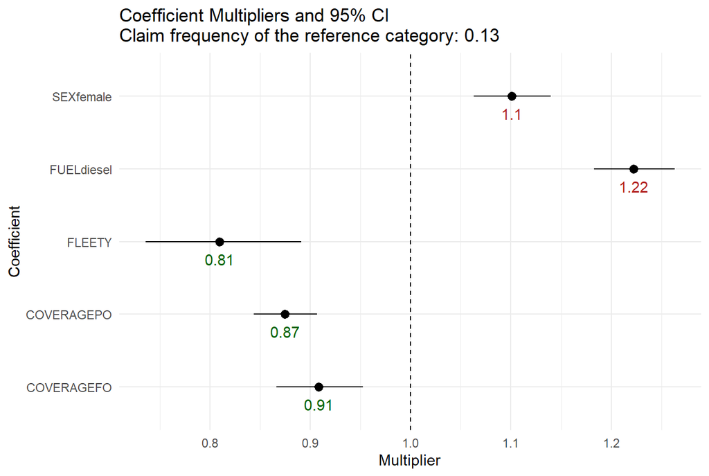

```r
check_summary <- function(result) {
    sum_mod <- summary(result$fit)
    coefficients <- sum_mod$coefficients %>% as.data.frame()
    coefficients$p.value <- coefficients[, "Pr(>|z|)"]
    coefficients <- coefficients %>% select(Estimate, `Std. Error`, p.value)
    coefficients$significant <- ifelse(coefficients$p.value < 0.05, "Yes", "No")
    coefficients$multiplier <- exp(coefficients[, "Estimate"])
    coefficients$multiplier_lb <- exp(coefficients[, "Estimate"] - 1.96 * coefficients[, "Std. Error"])
    coefficients$multiplier_ub <- exp(coefficients[, "Estimate"] + 1.96 * coefficients[, "Std. Error"])
    return(coefficients)
}

plot_summary <- function(result, add_text=FALSE) {
    coefficients <- check_summary(result)
    mult_df <- coefficients %>% filter(rownames(coefficients) != "(Intercept)")
    ggplot(mult_df, aes(x = rownames(mult_df), y = multiplier, ymin = multiplier_lb, ymax = multiplier_ub)) +
        geom_pointrange(
            color = ifelse(mult_df$significant == "Yes", "black", "firebrick")
        ) +
        geom_hline(yintercept = 1, linetype = "dashed") +
        {if(add_text) geom_text(
            aes(label = round(multiplier, 2)), vjust = 2,
            color = ifelse(mult_df$multiplier > 1, "firebrick", "darkgreen")
        ) else NULL} +
        coord_flip() +
        labs(x = "Coefficient", y = "Multiplier", title = sprintf("Coefficient Multipliers and 95%% CI\nClaim frequency of the reference category: %.2f", exp(result$fit$coefficients[1]))) +
        theme_minimal()
}
coefs <- check_summary(rcat)
plot_summary(rcat, add_text=TRUE)
```

We can conclude that the categorical variables were well-chosen in the EDA and have a significant impact in our model. The new model is better than the null model and needs no adaptation, so we can continue with the `rcat` model as our new baseline for further model development.

```r
base_mod <- rcat
base_f <- fcat
```

### 4.2.2 Adding Binned Continuous Variables

Next, we will add the binned continuous variables to our model to capture the potential non-linear effects of continuous predictors on the frequency of claims:

- BM_binned
- AGEPH_binned_merged
- AGEC_binned
- POWER_binned_merged

```r
fcontb <- paste0(base_f, " + ", paste(binned_continuous_features, collapse = " + "))
cat(sprintf("> Full formula with binned continuous variables: %s", fcontb))
```

```
> Full formula with binned continuous variables: NCLAIMS ~ offset(log(EXP)) + COVERAGE + FUEL + FLEET + SEX + BM_binned + AGEPH_binned_merged + AGEC_binned + POWER_binned_merged
```

```r
rcontb <- create_wflow_freq_glm(train_data, fcontb)
perf_metrics_df <- append_performance_metrics(name = "All Continuous Binned", formula = fcontb, result = rcontb)

test <- anova(base_mod$fit, rcontb$fit, test = "Chisq")
cat(sprintf("Is the full model with binned continuous variables a significant improvement over the categorical model? %s (p-value = %.4f)\n", ifelse(test$`Pr(>Chi)`[2] < 0.05, "Yes", "No"), test$`Pr(>Chi)`[2]))
```

```
Is the full model with binned continuous variables a significant improvement over the categorical model? Yes (p-value = 0.0000)
```

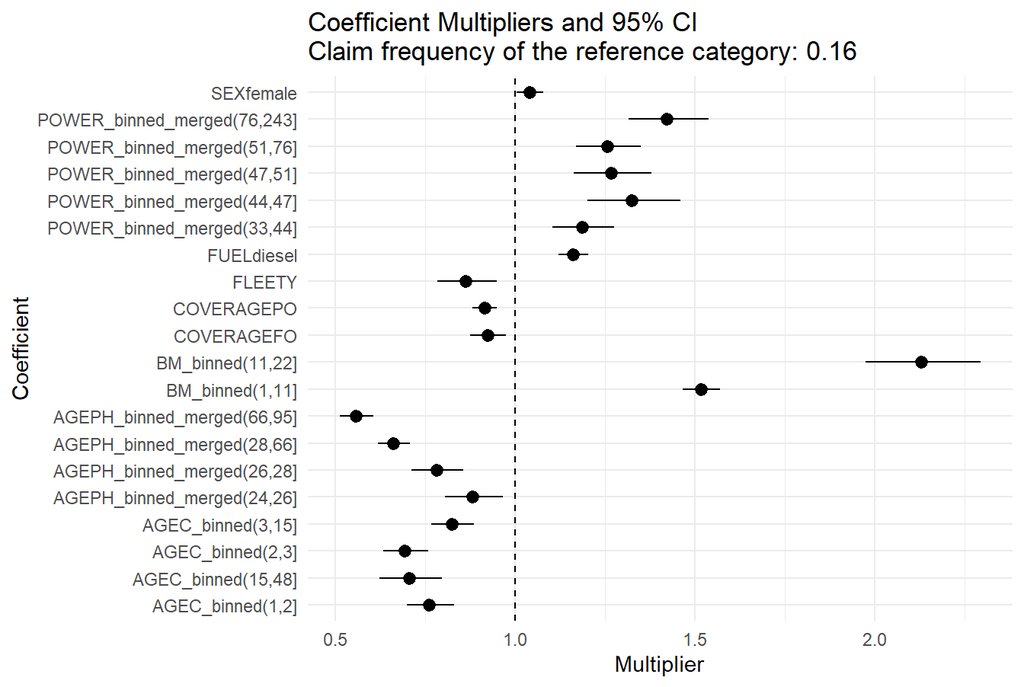

```r
coefs_contb <- check_summary(rcontb)
plot_summary(rcontb)
```

There are three main takeaways from the analysis of this more complex model:

1. With the addition of binned continuous variables, the `SEXfemale` variable is just barely significant, we can test whether the nested anova test supports its removal from the model.
2. The binned continuous variables themselves are all significant at the 95% confidence level. The WoE-based binning and merging strategy we applied is therefore effective in capturing significant non-linear effects of continuous predictors on the frequency of claims.
3. Some coefficients of the binned variables are very similar, we’ll consider merging them later for the final model.

Let’s proceed to remove the `SEX` variable from the model and evaluate the impact on model performance.

```r
large_mod <- rcontb$fit
fcontb_rsex <- gsub(" \\+ SEX", "", fcontb)
cat(sprintf("> Formula after removing SEX: %s", fcontb_rsex))
```

```
> Formula after removing SEX: NCLAIMS ~ offset(log(EXP)) + COVERAGE + FUEL + FLEET + BM_binned + AGEPH_binned_merged + AGEC_binned + POWER_binned_merged
```

```r
rcontb_rsex <- create_wflow_freq_glm(train_data, fcontb_rsex)
perf_metrics_df <- append_performance_metrics(name = "Continuous Binned without SEX", formula = fcontb_rsex, result = rcontb_rsex)
test_p2 <- anova(large_mod, rcontb_rsex$fit, test = "Chisq")
cat(sprintf("Are we loosing significant explanatory power by removing SEX? %s (p-value = %.4f)\n", ifelse(test_p2$`Pr(>Chi)`[2] < 0.05, "Yes", "No"), test_p2$`Pr(>Chi)`[2]))
```

```
Are we loosing significant explanatory power by removing SEX? Yes (p-value = 0.0266)
```

```r
coefs_contb_p2 <- check_summary(rcontb_rsex)
perf_metrics_df %>% arrange(CV_Prediction_Error) %>% select(-Formula) %>% kable(
    booktabs = TRUE, caption = "Performance Metrics for Frequency Models After Removing SEX"
)
```

Performance Metrics for Frequency Models After Removing SEX

| Model | AIC | BIC | Deviance | CV_Deviance | CV_Complexity | CV_Prediction_Error | CV_LogLoss |
| --- | --- | --- | --- | --- | --- | --- | --- |
| All Continuous Binned | 99985.22 | 100190.6 | 69898.75 | 69954.12 | 42 | 69996.12 | 0.3828870 |
| Continuous Binned without SEX | 99988.13 | 100183.7 | 69903.66 | 69957.85 | 40 | 69997.85 | 0.3829012 |
| Categorical Only | 101514.34 | 101573.0 | 71457.87 | 71469.36 | 12 | 71481.36 | 0.3886887 |
| Intercept Only | 101738.48 | 101748.3 | 71692.01 | 71694.04 | 2 | 71696.04 | 0.3895490 |

```r
base_f <- fcontb
base_mod <- rcontb
```

We see with that based on the prediction error, our best model includes the SEX. The complexity cost of 2 is justified by the reduction in deviance (confirmed by AIC). The anova test also confirms that removing the SEX variable results in a significant loss of explanatory power. Only the BIC criteria favors the simpler model as complexity is penalized more heavily. We will keep the SEX variable in our best model benchmark and continue with the next layer of covariates.